# Introduction to the `capl` R package

Joel D. Barnes, M.Sc. and Michelle D. Guerrero, Ph.D.

December 05, 2020

## Introduction

[The Canadian Assessment of Physical Literacy (CAPL)](https://www.capl-eclp.ca) is the first comprehensive protocol that can accurately and reliably assess a broad spectrum of skills and abilities that contribute to and characterize the physical literacy level of a participating child.

Physical literacy moves beyond just fitness, motor skill or motivation in isolation. The CAPL is unique in that it can assess the multiple aspects of physical literacy: physical competence, daily behaviour, motivation and confidence, and knowledge and understanding.

The domains of physical literacy are summarized in figure 1 of [the CAPL-2 manual](https://www.capl-eclp.ca/wp-content/uploads/2017/10/capl-2-manual-en.pdf) on page 6:

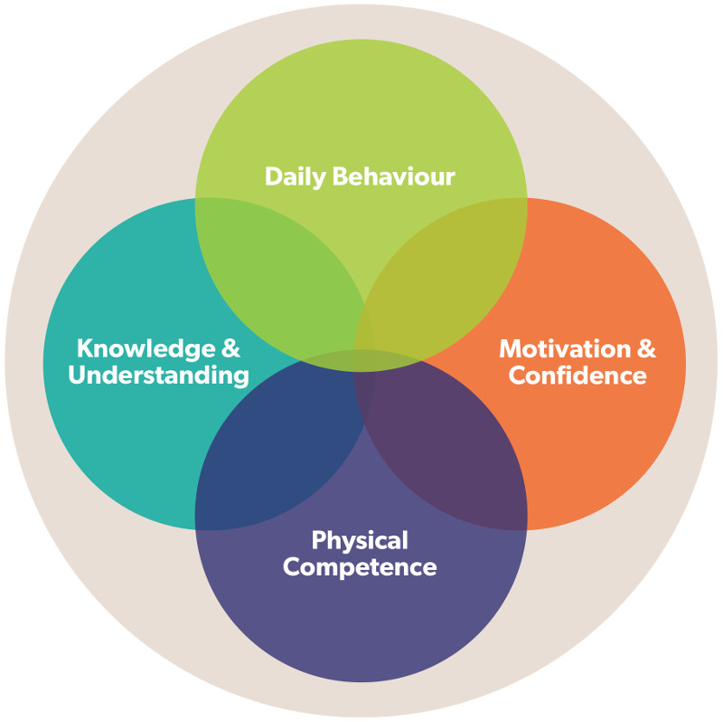

[The Healthy Active Living and Obesity Research Group (HALO)](https://www.haloresearch.ca) has been responsible for the systematic development of the CAPL since 2008. HALO’s test development efforts have been informed by the assessment of more than 10,000 children and with input from well over 100 researchers and practitioners within related fields of study.

The `capl` package contains tools enabling users to compute and visualize CAPL-2 (Canadian Assessment of Physical Literacy, Second Edition) scores and interpretations from raw data, all within the R environment without having to use the [CAPL-2 website](https://www.capl-eclp.ca).

## Installation

### GitHub

Users can download and install the most recent version of the `capl` package directly from GitHub ([www.github.com/barnzilla/capl](https://github.com/barnzilla/capl)) using the `devtools` R package.

```r
devtools::install_github("barnzilla/capl", upgrade = "never", build_vignettes = TRUE, force = TRUE)
library(capl)
```

Once the `capl` package is loaded, any available tutorials for the package, such as this vignette, can be accessed by calling the `browseVignettes()` function.

```r
browseVignettes("capl")
```

## Getting started

### Importing raw data

Users must first import their raw data before using the `capl` package to compute CAPL-2 scores and interpretations. The `import_capl_data()` function enables users to import data from an Excel workbook into the R global environment.

```r
data <- import_capl_data(
  file_path = "c:/path/to/raw-data.xlsx",
  sheet_name = "Sheet1"
)
```

### Required variables

The `capl` package requires 60 variables in order to compute CAPL-2 scores and interpretations. Users can use the `get_missing_capl_variables()` function to retrieve a list of the required variables. The required variables are outlined in the Details section of the documentation.

```r
?get_missing_capl_variables
```

The `capl` package is looking for 60 variables by the following names:

- `age`
- `gender`
- `pacer_lap_distance`
- `pacer_laps`
- `plank_time`
- `camsa_skill_score1`
- `camsa_time1`
- `camsa_skill_score2`
- `camsa_time2`
- `steps1`
- `time_on1`
- `time_off1`
- `non_wear_time1`
- `steps2`
- `time_on2`
- `time_off2`
- `non_wear_time2`
- `steps3`
- `time_on3`
- `time_off3`
- `non_wear_time3`
- `steps4`
- `time_on4`
- `time_off4`
- `non_wear_time4`
- `steps5`
- `time_on5`
- `time_off5`
- `non_wear_time5`
- `steps6`
- `time_on6`
- `time_off6`
- `non_wear_time6`
- `steps7`
- `time_on7`
- `time_off7`
- `non_wear_time7`
- `self_report_pa`
- `csappa1`
- `csappa2`
- `csappa3`
- `csappa4`
- `csappa5`
- `csappa6`
- `why_active1`
- `why_active2`
- `why_active3`
- `feelings_about_pa1`
- `feelings_about_pa2`
- `feelings_about_pa3`
- `pa_guideline`
- `crf_means`
- `ms_means`
- `sports_skill`
- `pa_is`
- `pa_is_also`
- `improve`
- `increase`
- `when_cooling_down`
- `heart_rate`

### Loading the pre-installed dataset

The `capl` package comes with a demo (fake) dataset of raw data, `capl_demo_data`, which contains 500 rows of participant data on the 60 variables that are required by the `capl` package. Users can load the demo dataset and start exploring.

```r
data("capl_demo_data")
```

The base R `str()` function allows users to get a sense of how the CAPL-2 raw data should be structured and named for downstream use in the `capl` package.

```r
str(capl_demo_data)
```

```
#> 'data.frame':    500 obs. of  60 variables:
#>  $ age               : int  8 9 9 8 12 10 12 10 12 9 ...
#>  $ gender            : chr  "Male" "Female" "Male" "f" ...
#>  $ pacer_lap_distance: num  15 20 20 15 20 15 15 15 15 NA ...
#>  $ pacer_laps        : int  23 31 169 50 63 15 32 143 43 182 ...
#>  $ plank_time        : int  274 282 9 228 252 110 21 185 6 41 ...
#>  $ camsa_skill_score1: int  14 5 6 13 2 9 4 11 5 11 ...
#>  $ camsa_time1       : int  34 27 13 35 21 NA NA 16 20 14 ...
#>  $ camsa_skill_score2: int  14 5 13 11 14 14 0 4 0 4 ...
#>  $ camsa_time2       : int  35 23 14 35 23 23 33 30 29 18 ...
#>  $ steps1            : int  30627 27788 8457 8769 14169 9610 29459 17112 30008 18270 ...
#>  $ time_on1          : chr  "5:13am" "6:13" "6:07" "6:13" ...
#>  $ time_off1         : chr  "22:00" NA "21:00" "22:00" ...
#>  $ non_wear_time1    : int  25 31 33 25 83 67 20 10 49 64 ...
#>  $ steps2            : int  14905 24750 30111 21077 15786 23828 24735 2621 20690 19652 ...
```

[output cut: 46 more lines]

The 60 required variables can also be quickly accessed by calling the base R `colnames()` function.

```r
colnames(capl_demo_data)
```

```
#>  [1] "age"                "gender"             "pacer_lap_distance"
#>  [4] "pacer_laps"         "plank_time"         "camsa_skill_score1"
#>  [7] "camsa_time1"        "camsa_skill_score2" "camsa_time2"
#> [10] "steps1"             "time_on1"           "time_off1"
#> [13] "non_wear_time1"     "steps2"             "time_on2"
#> [16] "time_off2"          "non_wear_time2"     "steps3"
#> [19] "time_on3"           "time_off3"          "non_wear_time3"
#> [22] "steps4"             "time_on4"           "time_off4"
#> [25] "non_wear_time4"     "steps5"             "time_on5"
#> [28] "time_off5"          "non_wear_time5"     "steps6"
#> [31] "time_on6"           "time_off6"          "non_wear_time6"
#> [34] "steps7"             "time_on7"           "time_off7"
#> [37] "non_wear_time7"     "self_report_pa"     "csappa1"
#> [40] "csappa2"            "csappa3"            "csappa4"
#> [43] "csappa5"            "csappa6"            "why_active1"
#> [46] "why_active2"        "why_active3"        "feelings_about_pa1"
#> [49] "feelings_about_pa2" "feelings_about_pa3" "pa_guideline"
#> [52] "crf_means"          "ms_means"           "sports_skill"
#> [55] "pa_is"              "pa_is_also"         "improve"
#> [58] "increase"           "when_cooling_down"  "heart_rate"
```

### Generating demo raw data

The `capl` package is also equipped with the `get_capl_demo_data()` function. This function allows users to randomly generate demo raw data and takes parameter `n` (set to 500 by default). This parameter is used to specify how many rows of demo raw data to generate and must, therefore, be an integer greater than zero. Users, for example, can randomly generate demo raw data for 10,000 participants by executing a single line of code:

```r
capl_demo_data2 <- get_capl_demo_data(n = 10000)
```

The base R `str()` function can be called to verify how many rows and columns of data were created.

```r
str(capl_demo_data2)
```

```
#> 'data.frame':    10000 obs. of  60 variables:
#>  $ age               : int  12 7 11 8 9 7 8 11 11 10 ...
#>  $ gender            : chr  "b" "Female" "f" "b" ...
#>  $ pacer_lap_distance: num  15 15 15 20 15 15 15 20 15 20 ...
#>  $ pacer_laps        : int  81 101 68 7 56 20 157 188 174 200 ...
#>  $ plank_time        : int  163 87 7 5 277 7 266 295 124 21 ...
#>  $ camsa_skill_score1: int  13 10 NA 12 8 4 12 NA 9 12 ...
#>  $ camsa_time1       : int  20 32 34 35 16 26 14 28 13 32 ...
#>  $ camsa_skill_score2: int  7 7 12 13 11 11 11 7 1 12 ...
#>  $ camsa_time2       : int  10 33 29 NA 31 12 21 NA 29 22 ...
#>  $ steps1            : int  7672 9212 29347 9353 12008 28783 23817 18419 15342 1688 ...
#>  $ time_on1          : chr  "07:00" "6:07" "05:00" "6:07" ...
#>  $ time_off1         : chr  NA "11:13pm" "21:00" "8:17pm" ...
#>  $ non_wear_time1    : int  87 87 74 6 3 15 57 8 86 69 ...
#>  $ steps2            : int  3955 24496 16455 2704 16478 24617 30894 29776 30351 4286 ...
```

[output cut: 46 more lines]

### Exporting data to Excel

If users prefer to examine the CAPL demo raw data in a workbook, the `export_capl_data()` function allows them to export data objects to Excel.

```r
export_capl_data(capl_demo_data2, "c:/path/to/store/capl_demo_data2.xlsx")
```

### Renaming variables

If users have imported their own raw data and plan to use the main function, `get_capl()`, in the `capl` package to compute CAPL-2 scores and interpretations, they must ensure their variables names match the names of the 60 required variables. Users can rename their variables by calling the `rename_variable()` function. This function takes three parameters: `x`, `search`, and `replace`. The `x` parameter must be the raw data object, the `search` parameter must be a character vector representing the variable name(s) to be renamed, and the `replace` parameter must be a character vector representing the new names for the variables specificed in the `search` parameter. Below we show how to rename variables using a fake dataset called `raw_data`.

```r
# Create fake data
raw_data <- data.frame(
  age_years = sample(8:12, 100, replace = TRUE),
  genders = sample(c("girl", "boy"), 100, replace = TRUE, prob = c(0.51, 0.49)),
  step_counts1 = sample(1000:30000, 100, replace = TRUE),
  step_counts2 = sample(1000:30000, 100, replace = TRUE),
  step_counts3 = sample(1000:30000, 100, replace = TRUE),
  step_counts4 = sample(1000:30000, 100, replace = TRUE),
  step_counts5 = sample(1000:30000, 100, replace = TRUE),
  step_counts6 = sample(1000:30000, 100, replace = TRUE),
  step_counts7 = sample(1000:30000, 100, replace = TRUE)
)

# Examine the structure of this data
str(raw_data)
```

```
#> 'data.frame':    100 obs. of  9 variables:
#>  $ age_years   : int  10 11 10 11 11 8 10 12 12 8 ...
#>  $ genders     : chr  "boy" "boy" "boy" "girl" ...
#>  $ step_counts1: int  6930 14781 6797 22762 3666 13552 3651 14065 26700 1936 ...
#>  $ step_counts2: int  4267 13317 13495 6661 13326 1889 14559 29832 19954 15079 ...
#>  $ step_counts3: int  2243 8629 18862 26511 17095 2716 24177 23688 27116 21413 ...
#>  $ step_counts4: int  20861 11286 21309 5103 25872 22440 28073 18007 11220 20425 ...
#>  $ step_counts5: int  18097 24685 9502 6611 12771 3021 19741 15188 5532 20976 ...
#>  $ step_counts6: int  5675 22665 26988 15556 9661 14763 4718 14617 7975 27037 ...
#>  $ step_counts7: int  16691 17282 10537 17198 7932 21352 11213 15149 26803 9321 ...
```

```r
# Rename the variables
raw_data <- rename_variable(
  x = raw_data,
  search = c(
    "age_years",
    "genders",
    "step_counts1",
    "step_counts2",
    "step_counts3",
    "step_counts4",
    "step_counts5",
    "step_counts6",
    "step_counts7"
  ),
  replace = c(
    "age",
    "gender",
    "steps1",
    "steps2",
    "steps3",
    "steps4",
    "steps5",
    "steps6",
    "steps7"
    )
)

# Examine the structure of this data
str(raw_data)
```

```
#> 'data.frame':    100 obs. of  9 variables:
#>  $ age   : int  10 11 10 11 11 8 10 12 12 8 ...
#>  $ gender: chr  "boy" "boy" "boy" "girl" ...
#>  $ steps1: int  6930 14781 6797 22762 3666 13552 3651 14065 26700 1936 ...
#>  $ steps2: int  4267 13317 13495 6661 13326 1889 14559 29832 19954 15079 ...
#>  $ steps3: int  2243 8629 18862 26511 17095 2716 24177 23688 27116 21413 ...
#>  $ steps4: int  20861 11286 21309 5103 25872 22440 28073 18007 11220 20425 ...
#>  $ steps5: int  18097 24685 9502 6611 12771 3021 19741 15188 5532 20976 ...
#>  $ steps6: int  5675 22665 26988 15556 9661 14763 4718 14617 7975 27037 ...
#>  $ steps7: int  16691 17282 10537 17198 7932 21352 11213 15149 26803 9321 ...
```

### Eliminating noisy errors with validation

One of the coding philosophies behind the `capl` package is to create a “quiet” user experience by suppressing “noisy” error and warning messages via validation. That is, the `capl` package returns missing or invalid values as NA values instead of throwing “noisy” errors that halt code execution. If any variable is missing, for example, the `get_capl()` function will continue to execute without throwing error or warning messages. The `get_missing_capl_variables()` function will create required variables that are missing and populate these variables with NA values. In order to implement the validation philosophy, every `capl` function enlists helper functions to validate the data. If a given value is not of the correct class or out of range, an NA will be returned.

#### Validation functions in the `capl` package

There are eight functions included in the `capl` package (displayed in alphabetical order) to help provide a “quiet” user experience:

- `validate_age()`
- `validate_character()`
- `validate_domain_score()`
- `validate_gender()`
- `validate_integer()`
- `validate_number()`
- `validate_scale()`
- `validate_steps()`

Users can learn more about these functions by accessing the documentation within the R environment.

```r
?validate_age
?validate_character
?validate_domain_score
?validate_gender
?validate_integer
?validate_number
?validate_scale
?validate_steps
```

#### Validation of age

The CAPL-2 is currently validated with 8- to 12-year-old children. However, when a function requires the `age` variable to execute a computation (e.g., `get_capl_interpretation()`), the `age` variable is validated via the `validate_age()` function.

```r
validated_age <- validate_age(c(7, 8, 9, 10, 11, 12, 13, "", NA, "12", 8.5))
```

Notice the NA values in the results.

```r
validated_age
```

```
#>  [1] NA  8  9 10 11 12 NA NA NA 12  8
```

The first element is NA because the original value is 7. The next five elements are identical to their original values because they are integers between 8 and 12. The seventh element is NA because the original value is 13. The next two elements are NA because the original values ("" and NA) are obviously invalid. The last element is 8, but notice that the original value is a decimal. Because 8.5 is between 8 and 12, it is considered valid but the floor of the value is returned since CAPL performs age-specific computations based on integer age.

#### Validation of gender

The CAPL-2 is currently validated for children who identify as boys or girls. When a function requires the `gender` variable to execute a computation (e.g., `get_capl_interpretation()`), the `gender` variable is validated via the `validate_gender()` function.

```r
validated_gender <- validate_gender(c("Girl", "GIRL", "g", "G", "Female", "f", "F", "", NA, 1))

validated_gender
```

```
#>  [1] "girl" "girl" "girl" "girl" "girl" "girl" "girl" NA     NA     "girl"
```

Notice the results again. This function accepts a number of case-insensitive options (e.g., “Girl”, “G”, “Female”, “F”, 1) for the female gender and returns a standardized “girl” value. The only two elements that are returned as NA have original values that are obviously invalid ("" and NA). The `validate_gender()` function behaves in a similar fashion for the male gender; it also accepts a number of case-insensitive options and returns a standardized “boy” value.

```r
validated_gender <- validate_gender(c("Boy", "BOY", "b", "B", "Male", "m", "M", "", NA, 0))

validated_gender
```

```
#>  [1] "boy" "boy" "boy" "boy" "boy" "boy" "boy" NA    NA    "boy"
```

## Computing CAPL-2 scores and interpretations

The CAPL-2 scoring system is nicely summarized in figure 2 of [the CAPL-2 manual](https://www.capl-eclp.ca/wp-content/uploads/2017/10/capl-2-manual-en.pdf) on page 7:

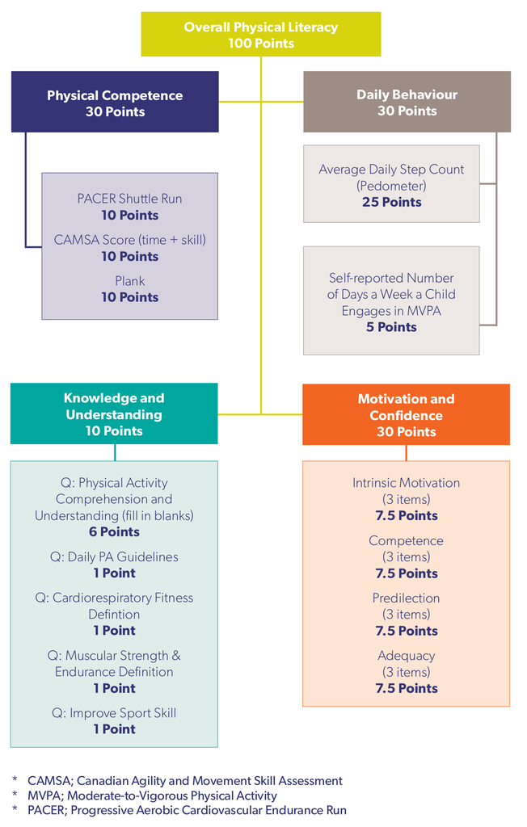

The main function in the `capl` package is the `get_capl()` function. This function takes two parameters, `raw_data` and `sort`. It computes the CAPL-2 scores in figure 2 above and their associated age- and gender-specific interpretations, row by row, by calling the other functions in the `capl` package. The `raw_data` parameter must be structured as a data frame and contain the raw data. The `sort` parameter is set to “asis” by default. This means the 40 new variables will be added to the data frame as they are computed. If `sort` is set to “abc”, all variables will be sorted alphabetically whereas if `sort` is set to “zyx”, all variables will be sorted in reverse alphabetical order. Once the raw data has been imported, computing the CAPL-2 scores and interpretations is as simple as executing one line of code:

```r
capl_results <- get_capl(raw_data = capl_demo_data, sort = "asis")
```

The addition of the 40 variables related to/including the CAPL-2 scores and interpretations can be confirmed by calling the base R `str()` function. As illustrated on the first line of the output, there are now 500 rows of participant data on 100 variables.

```r
str(capl_results, list.len = nrow(capl_results))
```

```
#> 'data.frame':    500 obs. of  100 variables:
#>  $ age                       : int  8 9 9 8 12 10 12 10 12 9 ...
#>  $ gender                    : chr  "Male" "Female" "Male" "f" ...
#>  $ pacer_lap_distance        : num  15 20 20 15 20 15 15 15 15 NA ...
#>  $ pacer_laps                : int  23 31 169 50 63 15 32 143 43 182 ...
#>  $ plank_time                : int  274 282 9 228 252 110 21 185 6 41 ...
#>  $ camsa_skill_score1        : int  14 5 6 13 2 9 4 11 5 11 ...
#>  $ camsa_time1               : int  34 27 13 35 21 NA NA 16 20 14 ...
#>  $ camsa_skill_score2        : int  14 5 13 11 14 14 0 4 0 4 ...
#>  $ camsa_time2               : int  35 23 14 35 23 23 33 30 29 18 ...
#>  $ steps1                    : int  30627 27788 8457 8769 14169 9610 29459 17112 30008 18270 ...
#>  $ time_on1                  : chr  "5:13am" "6:13" "6:07" "6:13" ...
#>  $ time_off1                 : chr  "22:00" NA "21:00" "22:00" ...
#>  $ non_wear_time1            : int  25 31 33 25 83 67 20 10 49 64 ...
#>  $ steps2                    : int  14905 24750 30111 21077 15786 23828 24735 2621 20690 19652 ...
```

[output cut: 86 more lines]

### Forty variables computed by get_capl()

The 40 new variables related to/including the CAPL-2 scores and interpretations that are output from the `get_capl()` function include:

- `pacer_laps_20m`
- `pacer_score`
- `pacer_interpretation`
- `plank_score`
- `plank_interpretation`
- `camsa_time_score1`
- `camsa_time_score2`
- `camsa_skill_time_score1`
- `camsa_skill_time_score2`
- `camsa_score`
- `camsa_interpretation`
- `pc_score`
- `pc_interpretation`
- `pc_status`
- `step_average`
- `valid_days`
- `step_score`
- `step_interpretation`
- `self_report_pa_score`
- `db_score`
- `db_interpretation`
- `db_status`
- `predilection_score`
- `adequacy_score`
- `intrinsic_motivation_score`
- `pa_competence_score`
- `mc_score`
- `mc_interpretation`
- `mc_status`
- `pa_guideline_score`
- `crf_means_score`
- `ms_means_score`
- `sports_skill_score`
- `fill_in_the_blanks_score`
- `ku_score`
- `ku_interpretation`
- `ku_status`
- `capl_score`
- `capl_interpretation`
- `capl_status`

## Computing CAPL-2 scores and interpretations manually

Some users may want to validate and compute individual variables and scores. The following sections introduce the helper functions in the order they appear when called in the `get_capl()` function.

### Physical competence functions

As illustrated in [the CAPL-2 manual](https://www.capl-eclp.ca/wp-content/uploads/2017/10/capl-2-manual-en.pdf) on page 43, the physical competence score is computed by summing the PACER (Progressive Aerobic Cardiovascular Endurance Run), plank, and CAMSA (Canadian Agility and Movement Skill Assessment) scores:

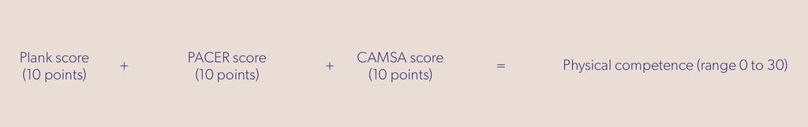

#### PACER 20-metre laps

The `pacer_laps_20m()` function converts PACER (Progressive Aerobic Cardiovascular Endurance Run) shuttle run laps to their equivalent in 20-metre laps. If laps are already 20-metre laps, they are returned unless outside the valid range (1-229). This variable is used to compute the PACER score.

```r
capl_demo_data$pacer_laps_20m <- get_pacer_20m_laps(
  lap_distance = capl_demo_data$pacer_lap_distance,
  laps_run = capl_demo_data$pacer_laps
)
```

```r
capl_demo_data$pacer_laps_20m
```

```
#>   [1]  18  31 169  38  63  12  25 110  33  NA 127  62  39  19  NA  84 145 166
#>  [19] 108 125  98 147  85  49   4 118 144  85 122  85 197   5 184  19  63 112
#>  [37]  89  46 178  35  69 122  54  79 120  85   1 187  59 178  47  55  89  98
#>  [55]  79 119  11  70  89  88  68  82 116  38 152 195   4  69 100  99  NA  88
#>  [73]  57  43  98 125 127   5  16 173  20  33  89  99  39  35  43 100 177  15
#>  [91] 141 141  39  NA   8  41  43   2 101  NA  54  78  90 176  40   2 122  58
#> [109]  98   5  51 112 101 122  12 177  38  92  31  53 102 200 138 166  62  31
#> [127]  86  75  87  56 147 140  45  51 136  74 148 194  67 142 172 121  NA  78
#> [145]  40  18  59 190  78  69  33  78  78  58  84 122  27 199 147  75 180  84
#> [163]  36 129  14 133  70  65   8  43 110  64  69 120 125  28 142 115 108  14
#> [181] 113 108  41  52  53  92 111 180 108 101 167  78  26  23  44 200 131  19
#> [199] 122 144  16  28 105 135  92 173  79  17  NA  74  63  32  37 161 116  NA
#> [217]  28  48  60  52  35  49  NA 117  48  60 110  45  72 109  NA  32  98  37
#> [235]  84  29  57 108 138 117 123  92  NA 112 140 171   9 191  NA 106 142  85
#> [253]  82  99   2 193 132 106  NA 152 188  61  36  NA 124  19  29 137 137  24
#> [271]  18 118 196  95  48 195  22 144 138  76  57 154  60 128 154  85  61   7
#> [289] 102 200  98 118 139  64 148  88 131  64 104  90 109 125  92 107 127 137
#> [307] 139  68  61  43 133 102 127 146  30  89  42 122  77  50  80 105  NA  46
#> [325] 154 122 173  10  78  41 150 140 129  30  84   3   6  74 186  NA   1  63
#> [343] 108  98  73 102 131 126 144  95  62 115 165  49  49 187 101 151  53  52
#> [361]  78 137   4  45 120 139   1  21  NA  76 134  16  12 125  63 140 144 102
#> [379] 141  62 134 142  90 193  NA  95  58  NA  28  21 150 100 185 140 142  NA
#> [397] 138  76  15  47  38 116 153  83  61  83  89  89 196  88 105  99 110  20
#> [415] 122 110 163  61 160  71 135   6 105 189   7  70  90  40 104 107  NA 165
#> [433]  27  78  42 167  51  57 128  44  25  NA  13  79  98  34 107 167  75  NA
#> [451] 119  13  82 136  21 140  58 126 144  35  25  29  97 195 131   3  18  66
#> [469]  NA  58  65  75 129  NA 196 175 112 134 145 141  65  10  NA  32  68  NA
#> [487] 144 135 112 130 112  52  51 142  24  NA  96 125  65  45
```

#### PACER score

The `get_pacer_score()` function computes a PACER (Progressive Aerobic Cardiovascular Endurance Run) score that ranges from zero to 10 based on the number of PACER laps run at a 20-metre distance. This score is used to compute the physical competence domain score variable.

```r
capl_demo_data$pacer_score <- get_pacer_score(capl_demo_data$pacer_laps_20m)
```

```r
capl_demo_data$pacer_score
```

```
#>   [1]  3  6 10  7 10  2  5 10  6 NA 10 10  7  3 NA 10 10 10 10 10 10 10 10  9  0
#>  [26] 10 10 10 10 10 10  1 10  3 10 10 10  9 10  7 10 10 10 10 10 10  0 10 10 10
#>  [51]  9 10 10 10 10 10  2 10 10 10 10 10 10  7 10 10  0 10 10 10 NA 10 10  8 10
#>  [76] 10 10  1  3 10  4  6 10 10  7  7  8 10 10  3 10 10  7 NA  1  8  8  0 10 NA
#> [101] 10 10 10 10  8  0 10 10 10  1 10 10 10 10  2 10  7 10  6 10 10 10 10 10 10
#> [126]  6 10 10 10 10 10 10  9 10 10 10 10 10 10 10 10 10 NA 10  8  3 10 10 10 10
#> [151]  6 10 10 10 10 10  5 10 10 10 10 10  7 10  2 10 10 10  1  8 10 10 10 10 10
#> [176]  5 10 10 10  2 10 10  8 10 10 10 10 10 10 10 10 10  5  4  8 10 10  3 10 10
#> [201]  3  5 10 10 10 10 10  3 NA 10 10  6  7 10 10 NA  5  9 10 10  7  9 NA 10  9
#> [226] 10 10  9 10 10 NA  6 10  7 10  5 10 10 10 10 10 10 NA 10 10 10  1 10 NA 10
#> [251] 10 10 10 10  0 10 10 10 NA 10 10 10  7 NA 10  3  5 10 10  4  3 10 10 10  9
#> [276] 10  4 10 10 10 10 10 10 10 10 10 10  1 10 10 10 10 10 10 10 10 10 10 10 10
#> [301] 10 10 10 10 10 10 10 10 10  8 10 10 10 10  6 10  8 10 10 10 10 10 NA  9 10
#> [326] 10 10  2 10  8 10 10 10  6 10  0  1 10 10 NA  0 10 10 10 10 10 10 10 10 10
#> [351] 10 10 10  9  9 10 10 10 10 10 10 10  0  9 10 10  0  4 NA 10 10  3  2 10 10
#> [376] 10 10 10 10 10 10 10 10 10 NA 10 10 NA  5  4 10 10 10 10 10 NA 10 10  3  9
#> [401]  7 10 10 10 10 10 10 10 10 10 10 10 10  4 10 10 10 10 10 10 10  1 10 10  1
#> [426] 10 10  8 10 10 NA 10  5 10  8 10 10 10 10  8  5 NA  2 10 10  6 10 10 10 NA
#> [451] 10  2 10 10  4 10 10 10 10  7  5  5 10 10 10  0  3 10 NA 10 10 10 10 NA 10
#> [476] 10 10 10 10 10 10  2 NA  6 10 NA 10 10 10 10 10 10 10 10  4 NA 10 10 10  9
```

#### PACER interpretation

The `get_capl_interpretation()` function computes an age- and gender-specific CAPL-2 interpretation for a given CAPL-2 protocol or domain score.

```r
capl_demo_data$pacer_interpretation <- get_capl_interpretation(
  age = capl_demo_data$age,
  gender = capl_demo_data$gender,
  score = capl_demo_data$pacer_score,
  protocol = "pacer"
)
```

```r
capl_demo_data$pacer_interpretation
```

[output not shown]

[output cut: 85 more lines]

#### Plank score

The `get_plank_score()` function computes a plank score that ranges from zero to 10 based on the duration of time (in seconds) for which a plank is held. This score is used to compute the physical competence domain score.

```r
capl_demo_data$plank_score <- get_plank_score(capl_demo_data$plank_time)
```

```r
capl_demo_data$plank_score
```

```
#>   [1] 10 10  0 10 10  9  1 10  0  3 10 10 10 10 10 10 10 10  0 10 10  5  3 10  9
#>  [26] 10 10  0 10  5  0  0  5 10  5 10  4  7 10  3  6 10  0 10  8  6 10 10  0 10
#>  [51]  5  9 10 10 10 10 10 10 10 10 10  8  0 10  4 10  2  9  0  6 10 10  7 10  4
#>  [76] 10 10 10  6  0 10 10 10 10  9 10 10 10 10  5  0 10 10 10  1  8 10 10  8  2
#> [101]  4 10  0 10  2 10  9 10  3 10 10  5 10  8  4 10 10 10 10  0 10 10  0 10 10
#> [126] 10 10 10 10 10  5 10  3 10  0 10  7  0 10  7  0 10 10 10  6 10 10 10  0  1
#> [151]  5 10 10  5  2 10  4 10 10 10 10  1 10  0  8 10 10  0  7  7 10 10  1 10 10
#> [176] 10 10 10 10 10  1  0  9 10 10 10 10 10 10 10  6  3  3 10 10  1 10 10 10  8
#> [201]  0  0 10  4 10  3 10 10  3  0 10  3 10 10 10  7 10  0 10 10 10  1 10 10  0
#> [226] 10 10 10  2  4 10  0  4  0 10 10  0  6 10 10 10  0 10 10  8 10 10 10  0 10
#> [251] 10 10  2 10 10 10 10  8 10 10 10  8 10 10 10 10  1 10 10 10 10 10 10  9  4
#> [276]  4 10 10 10 10 10  5  8 10 10 10 10 10  6 10  8 10  0 10  7  2 10  0 10 10
#> [301]  0  5 10  6 10 10 10 10 10 10  6 10 10  5  2  7 10 10 10 10 10 10 10 10 10
#> [326] 10  5  0  0 10 10 10  0  7 10 10 10 10  7 10 10 10 10 10 10 10 10  0  0 10
#> [351] 10 10 10 10 10  2 10 10 10  7  9 10 10 10  9  6 10  0 10 10 10 10  9 10 10
#> [376]  3 10 10 10 10  7  6 10 10  8 10 10 10  4  5 10 10 10 10  9 10  2 10 10  5
#> [401] 10  5  9 10 10  0 10 10 10 10 10 10  6 10 10  0 10  4 10  8  2  4  3 10  7
#> [426] 10 10 10 10  6 10 10  8 10 10 10 10 10 10  3  3 10 10 10  4 10 10  0 10 10
#> [451] 10 10  9  8 10 10  3 10  6  2  0 10 10  4  2  2 10  9 10  0  7 10  6  7  3
#> [476]  0  2 10 10  8 10 10 10 10  8 10  2  3 10  3  6  4 10 10 10 10 10  2 10  0
```

#### Plank interpretation

The `get_capl_interpretation()` function computes an age- and gender-specific CAPL-2 interpretation for a given CAPL-2 protocol or domain score.

```r
capl_demo_data$plank_interpretation <- get_capl_interpretation(
  age = capl_demo_data$age,
  gender = capl_demo_data$gender,
  score = capl_demo_data$plank_time,
  protocol = "plank"
)
```

```r
capl_demo_data$plank_interpretation
```

```
#>   [1] "excelling"   "excelling"   "beginning"   "excelling"   "excelling"
#>   [6] "excelling"   "beginning"   "excelling"   "beginning"   "progressing"
#>  [11] NA            "excelling"   NA            NA            "excelling"
#>  [16] "excelling"   "excelling"   "excelling"   "beginning"   "excelling"
#>  [21] "excelling"   "achieving"   "progressing" NA            NA
#>  [26] NA            "excelling"   NA            "excelling"   "progressing"
#>  [31] "beginning"   "beginning"   "progressing" NA            "progressing"
#>  [36] NA            NA            "achieving"   "excelling"   "progressing"
#>  [41] "progressing" "excelling"   "beginning"   "excelling"   "achieving"
#>  [46] "progressing" "excelling"   "excelling"   NA            NA
#>  [51] "achieving"   "excelling"   "excelling"   "excelling"   "excelling"
#>  [56] "excelling"   "excelling"   "excelling"   "excelling"   "excelling"
#>  [61] "excelling"   NA            "beginning"   "excelling"   "progressing"
#>  [66] NA            "progressing" "excelling"   NA            "achieving"
#>  [71] "excelling"   "excelling"   "achieving"   "excelling"   NA
```

[output cut: 85 more lines]

#### CAMSA time score

The `get_camsa_time()` function computes the CAMSA (Canadian Agility and Movement Skill Assessment) time score that ranges from one to 14 based on the time taken (in seconds) to complete a trial.

```r
# Trial 1
capl_demo_data$camsa_time_score1 <- get_camsa_time_score(capl_demo_data$camsa_time1)

# Trial 2
capl_demo_data$camsa_time_score2 <- get_camsa_time_score(capl_demo_data$camsa_time2)
```

```r
# Time scores for trial 1
capl_demo_data$camsa_time_score1
```

```
#>   [1]  1  3 14  1  6 NA NA 11  7 13  1 14 13 14  9 14  5 14  1  4  6  2 10 14 NA
#>  [26] 12  6 13 14  1  8  3  1  1  1  4  1 12  2 14 14  1  5  5  1  3  9  3  1 10
#>  [51]  7  1  8  1  2  4 11  2  6 13  6  3 14  6  4  1  1 NA  5 14  2 14  7 12 12
#>  [76]  8  7  1 NA 14 10 NA  6  1  5  7  1  1  4  1  1  1 NA  8  4 14  1 10  4 13
#> [101] NA  5 13 11  5  9  3  7 10  2  1 14 13 13  1 NA 14  2 13  1 11  4  1  8  1
#> [126] NA 14 14 NA 10  5 NA  4 12  1 NA 11 11 NA NA  8  8  1  3  1 14 14  1 10  5
#> [151]  1  1 11  6  3  5 14  2  4  1  5  6  7  1  1  8 12  2 12  1 14  6 14 12 14
#> [176] 13  1 14  8  5 10  5  7  2 11  2 14  4 11  5 11 14 14 14  1 14  3 NA  9  8
#> [201]  5  3  3  7  1 11  3 10 12  3 14 13  6 12  1 14  6  8  7  6 14  5  3 10  8
#> [226]  3 13  5  4  1 14  5  3 13  1 14 14  1 14  7  6 NA  6  2  5  1  1  4  1 14
#> [251] 14 NA  1  5  9 NA 14 14 14  1 10 14 10  9  3  3  1 10 NA 14  3 11  1  5  9
#> [276]  5  5  5  2  4  4 14 12 14 14 11  4  2  5  1 13 14  1  7 11  4  1  9 12 NA
#> [301] 14  2  1  1  6  1  1  2  1  1  3  7 11  8  6  4  1  1 14  1  3  2  7 14 14
#> [326] 10  8 11  8  1  5  9 10 14  8  2  3  1 14 13 13  7  1 14  9  1 NA  1 11 13
#> [351]  3  1  1  4 10 13  4  9  8 14  1  4 10 14 12  1  1 14 10 14  2  1  1 11  7
#> [376]  1 14  1 10 10 13  2  3  2 14  8  2 10 13  1  7  2  1  3 14 14 14 14 10 14
#> [401]  7  1 13 13  9 14  1 10  2  6 14  3  1  1  3  8  1 14  1  3  4 NA  8  1 14
#> [426]  2  4  8  1 13  1  1 11  3  5  7 10  4  2  8  5  1  5  4  1 14 14  1 12  2
#> [451]  5 10  8  1  3 14  7 14 14 12  6 NA  1 10 NA 13  6  1  1 13 12  5 14  1  1
#> [476]  4 14  2  9  3  1  3  1  7  2  2  1  4  7 10  1  4 11 NA 13 14 14 13  6  1
```

```r
# Time scores for trial 2
capl_demo_data$camsa_time_score2
```

```
#>   [1]  1  5 13  1  5  5  1  1  2  9  3  8  3 14  9 14 NA  1  4  1 10  5 14  1  1
#>  [26]  3  2 10  2  1  3 11 14 12 14 12 12  3 14 10  1 NA  1  1 14  1  6 11 13  5
#>  [51]  1 14 14 14  3  1  8 14 14  5  1  1 14  1 NA 14 11  1 10  3  7 14  8  4  1
#>  [76]  1  3  5  1  1 NA  8  1  5 NA  2  1 NA 10  2  1  6 14  7  3 12  8 14 14  6
#> [101] 14  3  4 13  1  9  5  5  9  1 14 14 11  1 10  6  1 14  2 11  5  1  4  5 11
#> [126]  1 14 11  1  1  4 14 14  2 NA  5  4 12  5  1 14  2  5 13 12 11 NA  2  4 12
#> [151]  4  5  2  1  8  5 14  1 12  2 10  1  8 14 14  6  5  5 13 14 14  9  3  5 12
#> [176]  4 10 10 14 14  5  1  8 14  4  2  6  4 14  6 14  9 14  1  1 NA 11  1  1 14
#> [201]  4  9  1 12  4 11  1  6  1  1  1 13  4 NA  6 14  1  1 14  7  6  1  1  1  4
#> [226] 12 14 NA  1 14  3 14 14  3  5  1  6 14  8 13 NA  7  6 14  3 14  6  2 14  5
#> [251]  2 14  2  4  1  2  7  3  1  1 13  4 NA 12 12 NA  2  1  1  7 12 10  2  1 11
#> [276] NA  9  4  5  1  2  3 14 14  1  6 NA  1 NA 13 14  2  1  9 12  6 14  2 NA 14
#> [301]  1 11  1 14  1  1  1  2  7  3 14  7 14  1 NA 14  5 10  4  1  1 14  9  2  4
#> [326]  5  5  7  8 13 11  3 12 14  1  2  2  1 10  1  1 NA 13 NA  4  1  2  7  5  1
#> [351]  9  1  1  5 11  1  1 14 11  5  5  8  1  4 13  8 14  5  1 12 13  3  5 14  9
#> [376]  2 12 14  1 13  9  1 14  3  1  2  6  2  3  8 14  2  5  9  2  4  1 10  3  8
#> [401]  1  1 10  3  1  1  1  1  2 14  2  7  3  3 14  1 14 13 14  2  6  3  1 14 14
#> [426] 12  8 14  5  2  1  1 14  3 14  1  2  2 11  4  8  1 NA 13 NA  5  2  3  4 14
#> [451]  5  1  1  1 NA  1  5  1 14 14  9  1 14  1  9 13  1 10 11  1  1 10  5  1  1
#> [476]  3  1  3  5  7  3 14 14  2  2  3  4  1 12 NA  1 10  8 14 13 12  4 NA  1 NA
```

#### CAMSA skill + time score

The `get_camsa_skill_time_score()` function computes the CAMSA (Canadian Agility and Movement Skill Assessment) skill + time score for a given trial. This score is used to compute the CAMSA score.

```r
# Trial 1
capl_demo_data$camsa_skill_time_score1 <- get_camsa_skill_time_score(
  camsa_skill_score = capl_demo_data$camsa_skill_score1,
  camsa_time_score = capl_demo_data$camsa_time_score1
)

# Trial 2
capl_demo_data$camsa_skill_time_score2 <- get_camsa_skill_time_score(
  camsa_skill_score = capl_demo_data$camsa_skill_score2,
  camsa_time_score = capl_demo_data$camsa_time_score2
)
```

```r
# Time scores for trial 1
capl_demo_data$camsa_skill_time_score1
```

```
#>   [1] 15  8 20 14  8 NA NA 22 12 24 15 24 24 18 13 24 11 18  9  5 10 16 19 21 NA
#>  [26] 24 17 23 28  8 NA  6 NA  8  5  7  6 18 15 18 16 11 17 16  5  6 21 10  1 22
#>  [51] 21  5 17 13 16 12 19 16 11 18 11 12 21 16 10 14 10 NA  9 NA 13 NA 17 21 17
#>  [76] 18 18 15 NA 25 21 NA 10 14  5 20 15  7  9  6 14  7 NA  9  9 27  6 16 10 NA
#> [101] NA 17 24 14  8 20 13 13 17 10  9 21 19 20 14 NA 21  6 25 15 19 15 14 19  8
#> [126] NA 21 26 NA 23 17 NA 17 17  5 NA NA 18 NA NA 18 NA 14  8 15 27 NA 12 21 17
#> [151]  8 NA 24 10 15  9 20 14 14 NA NA NA 18 15  9 17 21  9 23 13 23 10 27 NA 28
#> [176] NA  8 25 21 19 12 13 12 13 25 14 25  8 16 15 15 26 18 23 11 19 NA NA 20 12
#> [201] 12 16 12 19 15 16 16 17 25 10 18 23  8 17  3 25 19 15 21 14 28 16  6 20 19
#> [226] 12 19 NA 16  9 NA 11 13 17  9 18 19 14 21 11 10 NA 11 11 13 14 11 14 12 26
#> [251] 22 NA  5  6 13 NA 18 23 23  7 22 14 17 22  7  9  5 23 NA 28 15 22 15 15 16
#> [276]  8 10 18 12 16 11 19 20 19 22 16  9  7 15 10 22 21  6 21 21 13  5 23 18 NA
#> [301] 26 13  8  6 13 11 12 11 13  8 16 19 21 20 19 14  8  5 15 14 11  8 17 20 28
#> [326] 15 13 16 21  6 12 22 24 22 20 12  9 13 21 17 18 15 15 20 15 10 NA 11 13 22
#> [351] 10  9  7 15 16 25  9 18 NA 28  5  7 NA 21 24 12  7 28 NA 21  9 12 15 22 14
#> [376] 12 19 11 16 13 18 12 12  9 20 17 NA 21 21 15 15 11  7 15 25 26 19 28 NA 28
#> [401] 13  3 23 26 14 19  8 22  9 NA 26 17 11 11 10 20  5 27 14 NA  9 NA 11  6 20
#> [426]  6 18 14 15 17  7  8 16 13 17 20 21  8  6 18 NA 10  6 18 13 16 20  7 25  6
#> [451] NA NA 18  6 11 20 12 17 22 26 15 NA  9 17 NA 13 13  8  6 26 19  7 23 15  9
#> [476] 12 16 10 15 12  7 11 12 12  9  8  9 15 NA 17  6 18 15 NA 19 14 22 22 14 15
```

```r
# Time scores for trial 2
capl_demo_data$camsa_skill_time_score2
```

```
#>   [1] 15 10 26 12 19 19  1  5  2 13 12 18 14 26 18 26 NA 14  8 10 18  9 25 13 11
#>  [26] 13 NA 19 10  7  8 16 28 24 28 21 22 16 20 16 13 NA  3  8 27  6 14 23 24 16
#>  [51] 12 28 20 20 NA 11 13 18 22  6  5  8 28  7 NA 21 17  5 21 16 NA 26 NA 12 12
#>  [76] 13 17 10 12  5 NA  8 NA  8 NA  7  8 NA 18  9  5 15 19 14 13 16  9 22 19 17
#> [101] 18 12  6 23 13 16 17  9 13 14 26 20 21 NA 14 15  5 15 14 23 13 14  7 13 22
#> [126]  7 17 17 13 10 12 18 25 10 NA 16 10 18 14 12 25  7 17 26 21 23 NA 11 13 23
#> [151] 11 19  8 11 22 11 21  9 22 12 24  6 18 24 26 NA 16  7 22 24 22 18 17 18 16
#> [176] 12 19 17 25 27  9  5 11 27 13 11 15 11 26 10 18 11 22  7 12 NA 25 11  7 21
#> [201] 16 16 12 23 15 22  7 14 15  9 12 19 16 NA 10 NA 10  3 NA 14 10  5  7  8 13
#> [226] 18 22 NA 11 26 15 22 21 11 18 10 10 28 14 15 NA 15 14 21  9 27 15 11 24 18
#> [251]  6 19 11 10 12  8 18  5 12  2 17 14 NA 14 18 NA 11  8  7 18 24 11 15 15 22
#> [276] NA 20 18 16 15 11  8 23 19  5 14 NA 12 NA 19 22 12  5 18 22 19 23 11 NA NA
#> [301]  6 20  8 19 13  7  7  8 21  5 NA 20 25  8 NA 18 11 15 18 11 10 27 14  8  8
#> [326] 11 19 12 14 23 24 14 NA 28 13 NA  9  9 NA  6 12 NA 23 NA 18 10 11 11 12  9
#> [351] 14  9 13 17 20 15 13 20 20 11 19 17 11 18 NA 12 23 10 12 25 21  8  9 27 17
#> [376] 13 20 16  4 23 23  8 27 10 10 14 20 10 15 17 23 16 12 22 12  4  8 19  8 14
#> [401] 14 14 19 12 11 11  1 13  6 26  2 12 11 16 21 NA 26 14 18 10 19 13  7 28 26
#> [426] 16 14 14 13 12 14  7 24 16 16 15 15  8 11 10 15  9 NA 19 NA 10  9 10 15 25
#> [451] 10  6 13 13 NA 12 14  6 18 19 19 13 20  2 23 24 15 20 23  8  6 20 15  7  8
#> [476] 16 10 16 19 16 13 24 18 15  8 NA 16  7 12 NA  8 12 15 18 22 21 11 NA 15 NA
```

#### CAMSA score

The `get_camsa_score()` function computes the maximum CAMSA (Canadian Agility and Movement Skill Assessment) skill + time score for two trials and then divides by 2.8 so that the score is out of 10. This score is used to compute the physical literacy score.

```r
capl_demo_data$camsa_score <- get_camsa_score(
  camsa_skill_time_score1 = capl_demo_data$camsa_skill_time_score1,
  camsa_skill_time_score2 = capl_demo_data$camsa_skill_time_score2
)
```

```r
capl_demo_data$camsa_score
```

```
#>   [1]  5.357143  3.571429  9.285714  5.000000  6.785714        NA        NA
#>   [8]  7.857143  4.285714  8.571429  5.357143  8.571429  8.571429  9.285714
#>  [15]  6.428571  9.285714        NA  6.428571  3.214286  3.571429  6.428571
#>  [22]  5.714286  8.928571  7.500000        NA  8.571429        NA  8.214286
#>  [29] 10.000000  2.857143        NA  5.714286        NA  8.571429 10.000000
#>  [36]  7.500000  7.857143  6.428571  7.142857  6.428571  5.714286        NA
#>  [43]  6.071429  5.714286  9.642857  2.142857  7.500000  8.214286  8.571429
#>  [50]  7.857143  7.500000 10.000000  7.142857  7.142857        NA  4.285714
#>  [57]  6.785714  6.428571  7.857143  6.428571  3.928571  4.285714 10.000000
#>  [64]  5.714286        NA  7.500000  6.071429        NA  7.500000        NA
#>  [71]        NA        NA        NA  7.500000  6.071429  6.428571  6.428571
#>  [78]  5.357143        NA  8.928571        NA        NA        NA  5.000000
#>  [85]        NA  7.142857  5.357143        NA  6.428571  3.214286  5.000000
#>  [92]  5.357143        NA  5.000000  4.642857  9.642857  3.214286  7.857143
#>  [99]  6.785714        NA        NA  6.071429  8.571429  8.214286  4.642857
```

[output cut: 57 more lines]

#### CAMSA interpretation

The `get_capl_interpretation()` function computes an age- and gender-specific CAPL-2 interpretation for a given CAPL-2 protocol or domain score.

```r
capl_demo_data$camsa_interpretation <- get_capl_interpretation(
  age = capl_demo_data$age,
  gender = capl_demo_data$gender,
  score = capl_demo_data$camsa_score,
  protocol = "camsa"
)
```

```r
capl_demo_data$camsa_interpretation
```

```
#>   [1] "beginning"   "beginning"   "excelling"   "beginning"   "progressing"
#>   [6] NA            NA            "progressing" "beginning"   "excelling"
#>  [11] NA            "achieving"   NA            NA            "progressing"
#>  [16] "excelling"   NA            "progressing" "beginning"   "beginning"
#>  [21] "progressing" "beginning"   "excelling"   NA            NA
#>  [26] NA            NA            NA            "excelling"   "beginning"
#>  [31] NA            "beginning"   NA            NA            "excelling"
#>  [36] NA            NA            "progressing" "progressing" "progressing"
#>  [41] "beginning"   NA            "progressing" "beginning"   "excelling"
#>  [46] "beginning"   "progressing" "achieving"   NA            NA
#>  [51] "achieving"   "excelling"   "progressing" "progressing" NA
#>  [56] "beginning"   "progressing" "progressing" "progressing" "progressing"
#>  [61] "beginning"   NA            "excelling"   "progressing" NA
#>  [66] NA            "progressing" NA            NA            NA
#>  [71] NA            NA            NA            "progressing" NA
```

[output cut: 85 more lines]

#### Physical competence score

```r
capl_demo_data$pc_score <- get_pc_score(
  pacer_score = capl_demo_data$pacer_score,
  plank_score = capl_demo_data$plank_score,
  camsa_score = capl_demo_data$camsa_score
)
```

```r
capl_demo_data$pc_score
```

```
#>   [1] 19.5 24.0 15.0 22.0 30.0 16.5  9.0 30.0  9.0   NA 30.0 30.0 25.5 19.5   NA
#>  [16] 30.0 30.0 30.0 15.0 30.0 30.0 22.5 19.5 28.5 13.5 30.0 30.0 15.0 30.0 22.5
#>  [31] 15.0  1.5 22.5 19.5 25.0 30.0 21.0 24.0 30.0 15.0 24.0 30.0 15.0 30.0 27.0
#>  [46] 24.0 15.0 30.0 15.0 30.0 21.0 29.0 30.0 30.0 30.0 30.0 18.0 30.0 30.0 30.0
#>  [61] 30.0 27.0 20.0 25.5 21.0 30.0  3.0 28.5 15.0 24.0   NA 30.0 25.5 27.0 21.0
#>  [76] 30.0 30.0 16.5 13.5 15.0 21.0 24.0 30.0 25.0 24.0 25.5 27.0 30.0 30.0 12.0
#>  [91] 15.0 30.0 25.5 22.5  3.0 24.0 27.0 15.0 27.0   NA 21.0 30.0 15.0 30.0 15.0
#> [106] 15.0 28.5 30.0 19.5 16.0 30.0 22.5 30.0 27.0 11.0 30.0 25.5 30.0 24.0 15.0
#> [121] 30.0 30.0 15.0 30.0 30.0 24.0 30.0 30.0 30.0 30.0 22.5 30.0 18.0 30.0 15.0
#> [136] 30.0 25.5 15.0 30.0 25.5 15.0 30.0   NA 30.0 21.0 19.5 30.0 30.0 15.0 16.5
#> [151] 16.5 30.0 30.0 22.5 18.0 30.0 13.5 25.0 30.0 30.0 30.0 16.5 25.5 15.0 15.0
#> [166] 30.0 30.0 15.0 12.0 22.5 30.0 30.0 16.5 30.0 30.0 22.5 30.0 30.0 30.0 18.0
#> [181] 16.5 15.0 25.5 30.0 30.0 25.0 30.0 30.0 30.0 30.0 24.0 19.5 12.0 21.0 27.0
#> [196] 16.5 30.0 19.5 30.0 27.0  4.5  7.5 30.0 21.0 30.0 19.5 30.0 19.5   NA 15.0
#> [211] 30.0 13.5 25.5 30.0 30.0   NA 22.5 13.5 30.0 25.0 27.0 15.0   NA 30.0 13.5
```

[output cut: 19 more lines]

#### Physical competence interpretation

The `get_capl_interpretation()` function computes an age- and gender-specific CAPL-2 interpretation for a given CAPL-2 protocol or domain score.

```r
capl_demo_data$pc_interpretation <- get_capl_interpretation(
  age = capl_demo_data$age,
  gender = capl_demo_data$gender,
  score = capl_demo_data$pc_score,
  protocol = "pc"
)
```

```r
capl_demo_data$pc_interpretation
```

```
#>   [1] "achieving"   "excelling"   "progressing" "excelling"   "excelling"
#>   [6] "progressing" "beginning"   "excelling"   "beginning"   NA
#>  [11] NA            "excelling"   NA            NA            NA
#>  [16] "excelling"   "excelling"   "excelling"   "progressing" "excelling"
#>  [21] "excelling"   "excelling"   "achieving"   NA            NA
#>  [26] NA            "excelling"   NA            "excelling"   "achieving"
#>  [31] "progressing" "beginning"   "excelling"   NA            "excelling"
#>  [36] NA            NA            "excelling"   "excelling"   "progressing"
#>  [41] "excelling"   "excelling"   "progressing" "excelling"   "excelling"
#>  [46] "excelling"   "progressing" "excelling"   NA            NA
#>  [51] "excelling"   "excelling"   "excelling"   "excelling"   "excelling"
#>  [56] "excelling"   "progressing" "excelling"   "excelling"   "excelling"
#>  [61] "excelling"   NA            "achieving"   "excelling"   "achieving"
#>  [66] NA            "beginning"   "excelling"   NA            "excelling"
#>  [71] NA            "excelling"   "excelling"   "excelling"   NA
```

[output cut: 85 more lines]

#### Physical competence domain status

The `get_capl_domain_status()` function computes the status (“complete”, “missing interpretation”, “missing protocol” or “incomplete”) of a CAPL domain.

```r
capl_demo_data$pc_status <- get_capl_domain_status(
  x = capl_demo_data,
  domain = "pc"
)
```

```r
capl_demo_data$pc_status
```

```
#>   [1] "complete"               "complete"               "complete"
#>   [4] "complete"               "complete"               "missing protocol"
#>   [7] "missing protocol"       "complete"               "complete"
#>  [10] "incomplete"             "missing interpretation" "complete"
#>  [13] "missing interpretation" "missing interpretation" "incomplete"
#>  [16] "complete"               "missing protocol"       "complete"
#>  [19] "complete"               "complete"               "complete"
#>  [22] "complete"               "complete"               "missing interpretation"
#>  [25] "missing interpretation" "missing interpretation" "missing protocol"
#>  [28] "missing interpretation" "complete"               "complete"
#>  [31] "missing protocol"       "complete"               "missing protocol"
#>  [34] "missing interpretation" "complete"               "missing interpretation"
#>  [37] "missing interpretation" "complete"               "complete"
#>  [40] "complete"               "complete"               "missing protocol"
#>  [43] "complete"               "complete"               "complete"
```

[output cut: 152 more lines]

### Daily behaviour functions

As illustrated in [the CAPL-2 manual](https://www.capl-eclp.ca/wp-content/uploads/2017/10/capl-2-manual-en.pdf) on page 43, the formula for computing the daily behaviour score is:

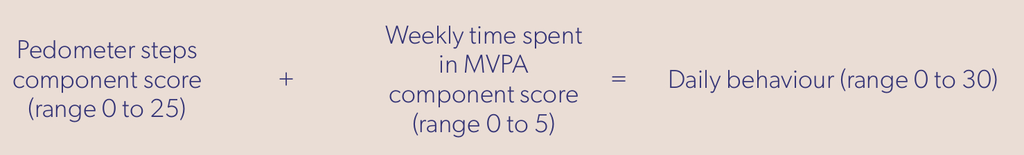

#### Step average

The `get_step_average()` function computes the daily arithmetic mean of a week of steps taken as measured by a pedometer. This variable is used to compute the step score.

```r
step_df <- get_step_average(capl_demo_data)
```

```r
str(step_df)
```

```
#> 'data.frame':    500 obs. of  9 variables:
#>  $ day1        : num  NA NA 8457 8769 14169 ...
#>  $ day2        : num  14905 24750 NA 21077 15786 ...
#>  $ day3        : num  21972 NA 14130 NA 18022 ...
#>  $ day4        : num  28084 27369 14315 NA 6993 ...
#>  $ day5        : num  14858 21112 16880 11707 20917 ...
#>  $ day6        : num  17705 NA NA 12235 27766 ...
#>  $ day7        : num  11067 13540 12106 18795 15039 ...
#>  $ valid_days  : int  6 4 5 5 7 6 7 7 6 6 ...
#>  $ step_average: num  18098 21693 13178 14517 16956 ...
```

```r
# Add the step average to the dataset
capl_demo_data$step_average <- step_df$step_average
```

```r
capl_demo_data$step_average
```

```
#>   [1] 18098 21693 13178 14517 16956 15255 16964 11217 15484 16110 20592  9690
#>  [13] 13268 10492  8191 17137 17574 15004 17104 14797 14610 24677 16391 15780
#>  [25] 16702 18576 14723 16389 16886 15383 16193 16330 12529 15559 13823 19799
#>  [37] 19027 20663 21974 16912 13020 20361 16285 21868 15697 11545 10465 17299
#>  [49] 14989  9863 19244 22727 17715 13539 16811 19710 10736 16569 19995 13647
#>  [61] 18848 13814 10218 21350 14978 15590  6361 14599 22695 12641 17406 10669
#>  [73] 15582 13489 13568 15639 13953  7900 19802 14654 13742 18182 13025 14514
#>  [85] 10707 25060 20010 21873 11736 18536 14424 13681 14932 23005 20833 19984
#>  [97] 18067 16457 21822 19952 17070 15288 16932 19190 16497 10412  9214 21416
#> [109]    NA 16792 21003  8517 24588 20734 13038 10231 17390 14517 11564 12506
#> [121] 18186 20292 17081 13962 13002 15281  9442 16720 10978 11025 12416 17754
#> [133] 17656 10830 16926 20410 14165 13581 15660 10031 12806 20440 13859 12895
#> [145] 13131  9794 14935 18777 16560 21703 15542 11607 15735 12854 15492 16158
#> [157] 20797 16280 10846 13008 12519 21301 19390 12013 19271 11710 20024 15647
#> [169] 13470 15133 15455  6679 15250 11733 21197 17131 15377 16228 15514 17054
```

[output cut: 27 more lines]

```r
wear_time1 <- get_pedometer_wear_time(
  time_on = capl_demo_data$time_on1,
  time_off = capl_demo_data$time_off1,
  non_wear_time = capl_demo_data$non_wear_time1
)
```

```r
wear_time1
```

```
#>   [1] 16.37    NA 14.33 15.37 14.12 14.67 17.50 17.83 15.13    NA 13.15 17.42
#>  [13] 14.88    NA 14.75 14.13 17.68 13.30 15.38 13.07 16.67 13.88 15.32 17.53
#>  [25] 15.00 14.67    NA 16.35    NA 13.68 15.45 15.65 14.85    NA 16.67    NA
#>  [37] 17.80 16.90 16.85 13.78 15.03 12.85 14.25 11.37 14.52 16.33 16.67 16.33
#>  [49] 15.08 15.83 13.90 17.23 11.72    NA 15.80 16.48 12.97 13.22 13.37 13.92
#>  [61] 14.32 17.62 16.62 11.60 13.12 18.40 14.20    NA 12.12 15.93 14.75 14.23
#>  [73] 17.40 12.92 14.63 17.65 14.48 14.25    NA 16.42 17.03 14.58 15.33 16.82
#>  [85] 12.95 14.45 16.77    NA 12.15 17.43    NA 16.97 18.52    NA 17.42 15.60
#>  [97] 17.65 13.80    NA 13.63 13.83 11.72 16.85 12.80 14.77 16.88 14.93 16.60
#> [109]    NA 14.38 16.12 15.15 12.60 16.98 13.72 12.50 14.80 13.23 16.27    NA
#> [121] 14.88 12.07    NA 15.67 14.38 18.03 14.98    NA    NA    NA    NA 14.70
#> [133] 13.38 13.57 17.57    NA 14.62 15.75 15.50 12.35 14.82 13.53 15.78 12.68
#> [145] 14.95 15.60 15.73 13.82    NA    NA 18.05 16.48 13.37 11.93    NA 13.67
#> [157] 13.98 14.73    NA 13.88 13.10 14.03 17.20 13.97 15.43 17.90    NA 13.25
#> [169] 15.82 11.52 14.62 14.43 15.33 12.88 14.02 16.43 15.85 14.37 13.20 15.48
```

[output cut: 27 more lines]

```r
valid_steps1 <- validate_steps(
  steps = capl_demo_data$steps1,
  wear_time = wear_time1
)
```

```r
valid_steps1
```

```
#>   [1]    NA    NA  8457  8769 14169  9610 29459 17112    NA    NA 17248  3355
#>  [13] 24598    NA  4461  6802 22886 11359  4443 16024 29259 27647 16084 12621
#>  [25] 12268  7801    NA 27912    NA  5187 28325  5421  2613    NA  3454    NA
#>  [37] 18392 18727    NA 14350 19843 28909  4376 25920 29033 12001 17053 28658
#>  [49]  2654  3741  9344 14136 24615    NA 23746 18382 16108  9054 10055 27796
#>  [61] 17747  1763 12925 22616 15816 27087  7309    NA 17448 24552 20614 22613
#>  [73]  9529 16273 23094 18946  4248 14276    NA  8050 27450 26960 23030  9955
#>  [85] 10805 23610 11304    NA 23266 23257    NA 11618 25138    NA 20026  6435
#>  [97] 12730 21297    NA 21832 11803 29608  9771 29072 24700 10064 20255  2574
#> [109]    NA  8968 25059 16861 17717  2933  8631 10052 25598 22404  5771    NA
#> [121] 19275 12241    NA  9876 12956 14995 15330    NA    NA    NA    NA 29222
#> [133] 25634  2212 22617    NA 11412 15123 15144  5547    NA 19113 13972  7991
#> [145]    NA 10375  1487  4610    NA    NA 24894 28248 10492 27681    NA 26918
#> [157] 22202 19509    NA  4831 21458 22153  1277  9399 12211  1709    NA 15369
#> [169]  4175 16306 27112  4078 20565 24711 16097    NA  2416 24568  3387 22382
```

[output cut: 27 more lines]

#### Step score

The `get_step_score()` function computes a step score that ranges from zero to 25 based on the average daily steps taken as measured by a pedometer. This score is used to compute the daily behaviour domain score.

```r
capl_demo_data$step_score <- get_step_score(capl_demo_data$step_average)
```

```r
capl_demo_data$step_score
```

```
#>   [1] 25 25 19 21 23 22 23 15 22 23 25 12 19 13  9 24 24 22 24 21 21 25 23 22 23
#>  [26] 25 21 23 23 22 23 23 18 22 20 25 25 25 25 23 19 25 23 25 22 16 13 24 21 12
#>  [51] 25 25 24 20 23 25 14 23 25 20 25 20 13 25 21 22  5 21 25 18 24 14 22 19 20
#>  [76] 22 20  8 25 21 20 25 19 21 14 25 25 25 16 25 21 20 21 25 25 25 25 23 25 25
#> [101] 24 22 23 25 23 13 11 25 NA 23 25 10 25 25 19 13 24 21 16 18 25 25 24 20 19
#> [126] 22 11 23 14 15 17 24 24 14 23 25 21 20 22 13 18 25 20 18 19 12 21 25 23 25
#> [151] 22 16 22 18 22 23 25 23 14 19 18 25 25 17 25 16 25 22 19 22 22  6 22 16 25
#> [176] 24 22 23 22 24 15 21 25 25 22 25 24 25 22 22 23 14 22 14 22 22 24 19 23 16
#> [201] 14 17  3 24 22 25 23 20 25 19 24 22 25 24 15 25 22 21 25 22 16 23 19 25 25
#> [226] 25 19 13 20 25 20 25 21 25 25 22 21 18 18 24 21 15 23 18 21 25 24 25 25 25
#> [251]  5  1 22 25 22 25 23 15 18 25 23 25 21 22 21 19 25 20 23 21 22 16 25 21 17
#> [276] 21 25 18 25 22 16 17 16 24 21 25 21 21 22 25 17 19 13 25 20 22 17 18 17 25
#> [301] 22 20 21 21 23 22 21 23 22 21 24 14 25 19 24 15 25 24 16 25 25 21 24 25 25
#> [326] 13 15 20 19 25 19 19 23 24 21 25 12 25 21 16 15 23 17 11 16 24 25 25 19 25
#> [351] 15 25 10 21 17 25 25 25 20 23 15 25 17 25 25 25 25 21 21 25 11 22 13 24 16
#> [376] 25 20 17 14 22 23 23 23 21 17 24 21 16 23 25 22 25 18 25 25 12 25 22 21 25
#> [401] 19 25 24 25 25 20 25 23 25 15 24 25 19 21 21 22 20 19 20 23 23 24 12 21  5
#> [426] 25  9 19 25 25 18 25 23 21 25 24 17 23 25 19 25 25  6 25 22 23 24 25 25 16
#> [451] 21 21 25 24 11 24 25 24 25 25 25 25 25 20 21 15 17  9 25 22 15 24 25 25 23
#> [476] 13 14 21 21 19 25 25 23 14 20 25 25 20 17 22 20  5 17 25 19 14 24 23 21 25
```

#### Self-reported physical activity score

The `get_self_report_pa()` function computes a score that ranges from zero to five based on the response to “During the past week (7 days), on how many days were you physically active for a total of at least 60 minutes per day (all the time you spent in activities that increased your heart rate and made you breathe hard)?” in [the CAPL-2 Questionnaire](https://www.capl-eclp.ca/wp-content/uploads/2018/02/CAPL-2-questionnaire.pdf). This score is used to compute the daily behaviour domain score.

```r
capl_demo_data$self_report_pa_score <- get_self_report_pa_score(capl_demo_data$self_report_pa)
```

```r
capl_demo_data$self_report_pa_score
```

```
#>   [1] NA  1  1  3  2  4 NA  5  5  5 NA  3  1  4  5  5  0  5  5  5  5  5  5 NA  5
#>  [26]  3  4  5  4  1  2  0  5  5  5  5  4  3  4  2  4  5  5  5  2  5  5 NA  5  5
#>  [51]  1  5  3  1  0  5  3  2  5  1  2  0  5 NA  3  5  4  0  3 NA  5  4  1 NA  0
#>  [76]  5  0  2  0 NA  5  5  1  1  3  3  5  2  5  4  5  5  4  3  1  4  2  1  5  5
#> [101]  5  2  1  4  3  2  5  5  3  2  2  5  5  5  2 NA  5  1  5  5 NA  5  5  1  0
#> [126]  4  5  4  0  0  5  4  5  0  5  5  5  5  2  5  5  5  2  5  1  3  5  5 NA  5
#> [151]  5  0  2  1  0  5  3  3  2  0  5  1  5  4  0  3  5  5  3  5  5  5  0  5  4
#> [176] NA  5  5  4  5  3  4  3  0  2  1  5  3  0  5  1  5  5  5  5  0  2  3  0  1
#> [201]  0  1  5  5  5  2  5  3  4  2  5  5  5  5  2  5  5  1  0  1  5  4  1  5  3
#> [226]  4  3  5  0  5  2  5  0 NA  5  3  3 NA  2  0  4  5  5  5  5  4  0  3  3  2
#> [251]  4  5  5  5  5  3  0  4  5  1  5  0  0  5  1  1  1  3  4  0  3  2  4  0  4
#> [276]  5  0  5  3  2  3  3  5  5  3  5  4  3  3  0  4 NA  5  2  5  3  5  5  1  2
#> [301]  5  5  2  5  5 NA  5  5 NA  5  5  4  1  5  3  5  0  5  0  3  2  0  3  0  0
#> [326]  3  1  4  5  5  1  5  5  5  5  1  3  0  1  5  4  5  3  0  3  0  4  1 NA  2
#> [351]  1  0  5  5  5  1  1  3  2  2  5  4  0  3  5  5  3  5  5  5  5  5  1  5  5
#> [376]  5  2 NA  4  0  5  1  2  5  5  5  5  2  1  5  0  5  2  5  5  5  0 NA  5  5
#> [401]  0  4  5  5  3  0  4  1  5 NA  2 NA  1  1  3  5  5  2  3  5  5  5  4  0  0
#> [426]  5  4  4  5  3  5 NA  0  1  5  2  4  1  5  4  5  0  3  5 NA  4  3  4  4  4
#> [451]  0  3 NA  5  5  3  1  5  5  5  5  1  3  2  5  0  5  1  0  2  0  2  5  5  3
#> [476]  1  5  5  1  2  4  5  4  5  3  1  2  5  5  2  1  5  5  3  5  5 NA  0  2 NA
```

#### Daily behaviour score

The `get_db_score()` function computes a daily behaviour domain score that ranges from zero to 30 based on the step and self-reported physical activity scores. This score is used to compute the overall physical literacy score.

```r
capl_demo_data$db_score <- get_db_score(
  step_score = capl_demo_data$step_score,
  self_report_pa_score = capl_demo_data$self_report_pa_score
)
```

```r
capl_demo_data$db_score
```

```
#>   [1] NA 26 20 24 25 26 NA 20 27 28 NA 15 20 17 14 29 24 27 29 26 26 30 28 NA 28
#>  [26] 28 25 28 27 23 25 23 23 27 25 30 29 28 29 25 23 30 28 30 24 21 18 NA 26 17
#>  [51] 26 30 27 21 23 30 17 25 30 21 27 20 18 NA 24 27  9 21 28 NA 29 18 23 NA 20
#>  [76] 27 20 10 25 NA 25 30 20 22 17 28 30 27 21 29 26 25 25 28 26 29 27 24 30 30
#> [101] 29 24 24 29 26 15 16 30 NA 25 27 15 30 30 21 NA 29 22 21 23 NA 30 29 21 19
#> [126] 26 16 27 14 15 22 28 29 14 28 30 26 25 24 18 23 30 22 23 20 15 26 30 NA 30
#> [151] 27 16 24 19 22 28 28 26 16 19 23 26 30 21 25 19 30 27 22 27 27 11 22 21 29
#> [176] NA 27 28 26 29 18 25 28 25 24 26 29 28 22 27 24 19 27 19 27 22 26 22 23 17
#> [201] 14 18  8 29 27 27 28 23 29 21 29 27 30 29 17 30 27 22 25 23 21 27 20 30 28
#> [226] 29 22 18 20 30 22 30 21 NA 30 25 24 NA 20 24 25 20 28 23 26 29 24 28 28 27
#> [251]  9  6 27 30 27 28 23 19 23 26 28 25 21 27 22 20 26 23 27 21 25 18 29 21 21
#> [276] 26 25 23 28 24 19 20 21 29 24 30 25 24 25 25 21 NA 18 27 25 25 22 23 18 27
#> [301] 27 25 23 26 28 NA 26 28 NA 26 29 18 26 24 27 20 25 29 16 28 27 21 27 25 25
#> [326] 16 16 24 24 30 20 24 28 29 26 26 15 25 22 21 19 28 20 11 19 24 29 26 NA 27
#> [351] 16 25 15 26 22 26 26 28 22 25 20 29 17 28 30 30 28 26 26 30 16 27 14 29 21
#> [376] 30 22 NA 18 22 28 24 25 26 22 29 26 18 24 30 22 30 20 30 30 17 25 NA 26 30
#> [401] 19 29 29 30 28 20 29 24 30 NA 26 NA 20 22 24 27 25 21 23 28 28 29 16 21  5
#> [426] 30 13 23 30 28 23 NA 23 22 30 26 21 24 30 23 30 25  9 30 NA 27 27 29 29 20
#> [451] 21 24 NA 29 16 27 26 29 30 30 30 26 28 22 26 15 22 10 25 24 15 26 30 30 26
#> [476] 14 19 26 22 21 29 30 27 19 23 26 27 25 22 24 21 10 22 28 24 19 NA 23 23 NA
```

#### Daily behaviour interpretation

The `get_capl_interpretation()` function computes an age- and gender-specific CAPL-2 interpretation for a given CAPL-2 protocol or domain score.

```r
capl_demo_data$db_interpretation <- get_capl_interpretation(
  age = capl_demo_data$age,
  gender = capl_demo_data$gender,
  score = capl_demo_data$db_score,
  protocol = "db"
)
```

```r
capl_demo_data$db_interpretation
```

```
#>   [1] NA            "achieving"   "progressing" "achieving"   "achieving"
#>   [6] "achieving"   NA            "progressing" "excelling"   "excelling"
#>  [11] NA            "progressing" NA            NA            "progressing"
#>  [16] "excelling"   "achieving"   "excelling"   "excelling"   "excelling"
#>  [21] "achieving"   "excelling"   "excelling"   NA            NA
#>  [26] NA            "excelling"   NA            "excelling"   "achieving"
#>  [31] "achieving"   "achieving"   "achieving"   NA            "excelling"
#>  [36] NA            NA            "excelling"   "excelling"   "achieving"
#>  [41] "achieving"   "excelling"   "excelling"   "excelling"   "achieving"
#>  [46] "progressing" "progressing" NA            NA            NA
#>  [51] "achieving"   "excelling"   "excelling"   "progressing" "achieving"
#>  [56] "excelling"   "progressing" "achieving"   "excelling"   "achieving"
#>  [61] "excelling"   NA            "progressing" NA            "achieving"
#>  [66] NA            "progressing" "progressing" NA            NA
#>  [71] "excelling"   "progressing" "achieving"   NA            NA
```

[output cut: 85 more lines]

#### Daily behaviour domain status

The `get_capl_domain_status()` function computes the status (“complete”, “missing interpretation”, “missing protocol” or “incomplete”) of a CAPL domain.

```r
capl_demo_data$db_status <- get_capl_domain_status(
  x = capl_demo_data,
  domain = "db"
)
```

```r
capl_demo_data$db_status
```

```
#>   [1] "incomplete"             "complete"               "complete"
#>   [4] "complete"               "complete"               "complete"
#>   [7] "incomplete"             "complete"               "complete"
#>  [10] "complete"               "incomplete"             "complete"
#>  [13] "missing interpretation" "missing interpretation" "complete"
#>  [16] "complete"               "complete"               "complete"
#>  [19] "complete"               "complete"               "complete"
#>  [22] "complete"               "complete"               "incomplete"
#>  [25] "missing interpretation" "missing interpretation" "complete"
#>  [28] "missing interpretation" "complete"               "complete"
#>  [31] "complete"               "complete"               "complete"
#>  [34] "missing interpretation" "complete"               "missing interpretation"
#>  [37] "missing interpretation" "complete"               "complete"
#>  [40] "complete"               "complete"               "complete"
#>  [43] "complete"               "complete"               "complete"
```

[output cut: 152 more lines]

### Motivation and confidence functions

As illustrated in [the CAPL-2 manual](https://www.capl-eclp.ca/wp-content/uploads/2017/10/capl-2-manual-en.pdf) on page 79, the formula for computing the motivation and confidence score is:

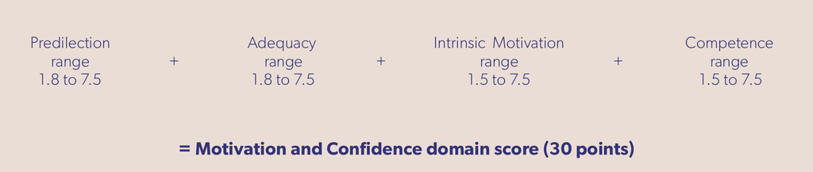

#### Predilection score

The `get_predilection_score()` function computes a predilection score (`predilection_score`) that ranges from 1.8 to 7.5 based on responses to three items from the Children’s Self-Perceptions of Adequacy in and Predilection for Physical Activity (Hay, 1992) as they appear in [the CAPL-2 questionnaire](https://www.capl-eclp.ca/wp-content/uploads/2018/02/CAPL-2-questionnaire.pdf). This score is used to compute the motivation and confidence domain score.

```r
capl_demo_data$predilection_score <- get_predilection_score(
  csappa1 = capl_demo_data$csappa1,
  csappa3 = capl_demo_data$csappa3,
  csappa5 = capl_demo_data$csappa5
)
```

```r
capl_demo_data$predilection_score
```

```
#>   [1] 3.6 4.9 5.5 3.0  NA 3.0 6.2 4.9 4.8 4.9 3.0 3.0 5.6 4.9 5.5 5.5 4.9 4.3
#>  [19] 5.6 3.6 4.2 3.6 6.1 3.6 4.3 4.8 5.6 3.0 4.3 4.3 6.1 4.9 6.2 3.6 6.8 5.5
#>  [37] 5.5 6.2 3.0 2.4 4.3 3.6 5.5 6.1  NA 4.3 2.4 4.9 4.9  NA 5.5 4.3 4.2 4.2
#>  [55] 4.9 6.2 4.3 5.5 1.8 3.7 4.9 3.7 6.8 4.8 6.2 4.2 3.7 1.8 5.5 3.0 5.5 4.2
#>  [73] 4.8 5.5 4.9 3.6 4.9 3.7 3.6 3.6 4.9 6.2 4.2 3.7 3.7 3.6 3.0 2.4 4.2 4.2
#>  [91] 3.0 5.4 5.5 6.2 4.3 3.6 5.6 6.1 4.9  NA 4.2 5.5 6.8 4.8 4.9 4.9 4.9 2.4
#> [109] 4.8 3.0 3.6 3.6 4.9 3.6 4.3 3.7 2.4 3.0 3.6 4.2 4.3 4.3 6.8 5.6 4.9 6.2
#> [127] 3.0 3.0 5.5 3.6 4.2 3.7 6.1 3.7 3.6 6.2 6.1 4.8 3.6 4.9 1.8 5.6 3.0 4.9
#> [145] 4.9 4.8 3.0 4.8 4.2 4.9 2.4 5.5 3.7 4.3 3.6 3.0 4.8 5.5 7.5 4.9 4.8 4.2
#> [163] 3.0 2.4 5.5 2.4 5.5 6.1 3.6 5.5 4.3 4.2 4.3  NA 6.1 3.6 4.9 5.6 3.7 2.4
#> [181] 5.6 3.0 4.2 3.7 5.4 6.2 4.2 4.3 3.6 5.5 5.5 3.6 4.9 3.6 4.9 3.7 4.9 4.2
#> [199] 4.9 4.3 6.2 2.4 4.3 3.6 6.8 4.9 4.9 6.1 2.4 7.5 5.5 4.3 6.2 5.6 4.8 3.0
#> [217] 5.6 3.6 4.9 6.1 4.3 4.8 4.2 3.6 4.3 6.1 6.8 4.9 3.0 3.6 3.0 5.6 4.9 4.3
#> [235] 6.2 5.6 1.8  NA 5.5 3.6 4.3 6.2 4.9 4.8 3.6 5.5 4.9 5.5 4.9 6.1 4.9 4.3
#> [253] 6.8 3.6 4.9 4.2 4.8 5.5 4.2 3.0 6.2 4.8 3.6 4.2 4.3 4.9 7.5 4.3 5.5 4.9
#> [271] 1.8 3.6 5.5 4.2 5.6 4.2 4.9 3.0 3.7 4.3 4.9 4.8 3.0 3.6 4.9 4.9 6.1 4.9
#> [289] 4.2 3.6 5.5 5.5 2.4 2.4 3.7 5.5 5.4 6.2 3.7 6.8 4.2 7.5 5.6 3.7 4.2 5.5
#> [307] 4.3 5.4 4.9 3.6 4.8 4.8 4.2 6.1 4.3 3.0 3.7 6.8 3.6 3.0 6.2 4.8 4.2 5.5
#> [325] 4.3 4.2 4.9 4.3 3.0 3.0 4.9 4.3 4.3 6.2 6.1 4.3 4.2 5.6 3.6 6.1 4.9 4.3
#> [343] 7.5 6.2 4.3 3.6 6.2 4.2 4.2 4.3 2.4 3.6 1.8 5.5 5.5 5.5 3.7 7.5 5.5 5.5
#> [361] 7.5 6.2 3.7 3.6 3.6 2.4 3.0 3.0 4.9 6.1 4.9 5.5 4.3 3.0 4.9 3.6 4.3 4.2
#> [379] 4.2 3.7 3.0 3.6 4.3 4.3 4.9 3.0 4.9 4.3 4.2 3.6 6.1 4.2 4.9 4.9 5.5 6.8
#> [397] 5.6 4.9 4.2 3.6 3.6 4.2 4.2 4.3 4.3 6.1 6.1 5.6 3.6 5.5 5.5 3.0 6.1 3.0
#> [415] 6.2 5.6 4.9 3.0 3.6 4.3 3.6 3.7 6.1 2.4 5.6 4.9 5.5 7.5 5.5 3.7 4.3 6.2
#> [433] 4.9 4.9 4.2 4.3 3.6 4.2 4.2 3.6 3.0 5.5 2.4 3.6 4.8 6.1 4.2 2.4 3.0 4.9
#> [451] 3.7 4.9 3.6 5.6 3.6 4.9 4.8 4.2 3.0 6.8 5.5 3.7 3.6 6.2 4.9 3.6 3.6 3.7
#> [469] 3.0 4.2 3.0 4.3 6.2 6.8 5.4 4.3 4.3  NA 6.1 3.0 4.9 3.0 4.9 6.8 5.5 4.9
#> [487] 6.1 3.0 4.9 4.2 4.2 4.2 2.4 3.6 4.3 5.5 3.7 6.1 2.4 4.2
```

#### Adequacy score

The `get_adequacy_score()` function computes an adequacy score that ranges from 1.8 to 7.5 based on responses to three items from the Children’s Self-Perceptions of Adequacy in and Predilection for Physical Activity Questionnaire (Hay, 1992) as they appear in [the CAPL-2 questionnaire](https://www.capl-eclp.ca/wp-content/uploads/2018/02/CAPL-2-questionnaire.pdf). This score is used to compute the motivation and confidence domain score.

```r
capl_demo_data$adequacy_score <- get_adequacy_score(
  csappa2 = capl_demo_data$csappa2,
  csappa4 = capl_demo_data$csappa4,
  csappa6 = capl_demo_data$csappa6
)
```

```r
capl_demo_data$adequacy_score
```

```
#>   [1] 2.4 5.5 7.5 4.3 5.5 5.5 4.2 4.3 3.6 4.3 6.2 4.9 4.9 4.2 4.3 5.6 4.2 4.8
#>  [19] 4.8 6.2 4.3 4.8 4.9 3.6 6.8 4.3 6.2 6.2 4.3 7.5 6.1 5.6 4.9 6.2 6.2 2.4
#>  [37] 4.2 5.6 5.6 4.2 5.5 4.9 5.5 4.9 4.2 6.2 5.6 6.2 4.9 4.2 3.6 3.7 3.6 6.8
#>  [55] 1.8 3.6 5.6 4.9 3.6 3.0 3.6 4.9 3.7 4.9 3.6 3.7 4.2 5.6 6.1 4.9 3.6 3.0
#>  [73] 2.4 4.3 6.1 3.0 3.0 3.7 4.9 4.3 5.4 5.5 3.0 2.4 6.1 5.6 5.5 3.7 4.2 2.4
#>  [91] 5.6 4.9 3.0 5.6 4.9 3.6 4.9 6.8 4.9 2.4 5.6 4.8 4.2 3.0 4.9 3.0 3.0 3.7
#> [109] 4.9 3.7 6.2 4.9 5.5 5.6 5.6 4.8 3.7 6.2 3.0 5.4 4.9 3.6 5.4 3.0 4.8 3.6
#> [127] 4.8 4.2 4.2 2.4 4.9 4.3 6.2 2.4 4.9 4.9 4.9 4.2 4.9 5.5 4.9 5.5 7.5 5.6
#> [145] 5.5 3.0 4.9 6.1 4.9 5.5 3.0 5.6 6.2 4.9 4.3 4.9 5.6 4.2 2.4 5.5 4.9 3.7
#> [163] 4.3 4.3 4.9 4.3 6.1 4.8 4.9 5.5 6.2 6.1 3.6 2.4 3.6 4.9 6.2 4.3 4.3 4.2
#> [181] 3.6 3.6 3.6 6.1 7.5 3.0 5.5 4.9 5.6 3.6 4.3 5.4 3.7 3.0 6.2 6.8 2.4 3.0
#> [199] 6.1 4.9 3.0 4.8 3.6 3.6 6.1 2.4 5.5 4.8 6.1 4.9 5.5 6.2 3.0 4.3 5.6 4.2
#> [217] 4.3 3.7 4.9 5.5 6.2 4.3 4.9 5.4 4.2 3.6 6.1 6.8 7.5 3.0 4.2 3.6 5.5 4.2
#> [235] 4.2 5.5 3.6 3.7 3.0  NA 5.5 3.6 4.2 3.7 6.8 4.9 4.9 5.5 3.0 3.7 4.3 3.0
#> [253] 6.1 4.9 1.8 6.2 4.2 4.2 5.6 5.5 4.9 4.3 5.6 4.2 6.1 4.2 4.9 4.2 3.7 4.8
#> [271] 3.6 2.4 3.6 3.6 4.3 5.6 4.9 4.9 4.9 6.1 6.1 3.6 6.1 3.6 3.7 4.9 3.6 4.2
#> [289] 3.6 4.2 5.5 3.0 4.8 4.9 5.5 3.7  NA 3.7 5.4 3.6 4.3 5.5 3.6 4.2 5.6 4.2
#> [307] 6.8 3.0 6.1 6.1 3.6  NA 4.8 5.5 3.6 6.1 4.3 3.0 6.8 6.2 3.0 6.1 1.8 3.7
#> [325] 3.6 3.7 6.2 4.8 3.7 3.6 3.6 3.0 4.8 3.0 3.0 4.9 5.5 2.4 5.6 6.8 6.2 6.1
#> [343] 3.0 4.9 4.9 6.2 2.4 3.0 4.2 3.6 1.8 4.9 4.2 4.9 4.9 5.6 3.0 4.9 6.1 6.1
#> [361] 4.2 4.9 6.2 3.6 4.9 4.3 3.0 6.1 4.3 3.7 3.7 3.0 4.2 3.6 3.0 6.1 4.3 6.1
#> [379] 2.4 5.5 5.6 5.5 5.5 4.9 5.5 4.2 4.2 4.3 4.3 4.9 3.0 5.5 5.6 5.6 3.6 6.1
#> [397] 5.6 3.0 2.4 2.4 3.7 3.0 4.2 2.4 4.3 6.8 4.8 3.6 3.6 5.6 3.0 4.3 4.2 4.9
#> [415] 6.2 3.7 4.9 3.6 6.8 3.6 5.4 4.9 4.8 4.2 5.5 5.5 5.5 4.8 4.2 4.9 3.7 5.6
#> [433] 3.6 4.9 5.6 3.6 3.7 7.5 5.5 4.8 4.9 4.2 5.5 4.3 5.5 4.2 6.1 2.4 4.8 3.0
#> [451] 5.4 5.5 3.6 1.8 6.1 1.8 4.8 4.9 2.4 4.2 4.3 3.6 1.8 3.7 4.3 3.0 2.4 5.6
#> [469] 4.2 5.5 3.7 6.8 4.3 4.3 5.5 4.2 4.3 5.6 3.0 3.0 6.1 6.8 4.2 5.6 4.9 3.7
#> [487] 5.5 4.3 4.8 7.5 6.2 7.5 5.5 4.9 1.8 5.5 4.2 3.7 4.2 2.4
```

#### Intrinsic motivation score

The `get_intrinsic_motivation_score()` function computes an intrinsic motivation score that ranges from 1.5 to 7.5 based on responses to three items from the Behavioral Regulation in Exercise Questionnaire (BREQ) as they appear in [the CAPL-2 questionnaire](https://www.capl-eclp.ca/wp-content/uploads/2018/02/CAPL-2-questionnaire.pdf). This score is used to compute the motivation and confidence domain score.

```r
capl_demo_data$intrinsic_motivation_score <- get_intrinsic_motivation_score(
  why_active1 = capl_demo_data$why_active1,
  why_active2 = capl_demo_data$why_active2,
  why_active3 = capl_demo_data$why_active3
)
```

```r
capl_demo_data$intrinsic_motivation_score
```

```
#>   [1] 6.0 4.5 5.0 4.5 4.0 5.5 6.5  NA 5.5  NA 6.5 5.0 4.0 3.5  NA 6.0 4.5 4.5
#>  [19] 5.0 3.0 2.0 2.5 3.5  NA 5.0 4.0 4.5 7.0 3.5 4.0  NA 6.0 5.0 3.5  NA 4.5
#>  [37] 4.5  NA 5.0 5.0 4.0 3.5 6.5 4.0  NA 4.5 3.0  NA 5.0 5.0 4.0 6.5  NA 4.0
#>  [55] 5.0 3.5 6.5 2.5 6.5 5.0 6.0 5.5 4.5 3.5 3.0 2.5 4.5 4.5 4.5 4.5 4.5 3.0
#>  [73] 4.5 4.5 5.0 5.0 2.5 6.5 5.5 4.5 6.0 2.5 4.0 7.0 4.5  NA 3.5  NA 3.5 3.0
#>  [91] 4.0 4.0 5.0 5.0 2.5  NA 3.5 6.0 1.5 6.5 5.5 5.5 5.5 4.0 4.0 4.0  NA 3.0
#> [109]  NA 4.0 5.0 5.5 3.5 4.0 3.0 4.0 6.5 3.5 6.0 3.0 4.5 6.0  NA 3.0 3.5  NA
#> [127] 5.0 3.0  NA 5.5 5.5 6.5 4.0  NA 5.0 5.0 5.0  NA 3.0 2.5  NA 4.0 6.0 5.0
#> [145] 5.0 3.5 4.5 5.0  NA 4.5 2.5 4.0 4.0 5.5 3.0 7.0 5.0 5.0 5.0  NA 5.5 7.5
#> [163] 4.0 2.5 3.5 5.5  NA 4.5 6.0 5.0 5.0 5.5 2.5 4.5 5.5 2.0 5.0 7.0  NA 6.0
#> [181] 2.5 2.5 3.5 5.0 3.5 4.5 5.5 6.5 5.5 4.5 4.5 6.0 5.5 6.0 4.0  NA 2.5 6.5
#> [199]  NA 2.5 3.0 5.0 2.5 5.5 5.5  NA 3.0 3.0 4.5 4.5 3.0 3.0 5.0  NA 6.0 3.5
#> [217] 4.5 7.0 2.5 3.0 3.0 5.0 4.5 6.5 4.5 5.5  NA 5.0 6.0 5.5  NA 3.0 2.5  NA
#> [235] 4.5 4.0 4.0 3.5 4.5 5.0 4.0 7.5 2.0 6.5 5.0 5.0 3.5  NA 4.5 2.5 3.0  NA
#> [253] 4.5 5.5  NA  NA 5.5 3.5 5.0 5.5 4.5 4.5 4.0 4.5  NA 5.0 6.5 5.5 4.5 6.0
#> [271] 4.0 5.0  NA 5.5 4.0 4.0 4.0 5.0 5.5 6.5  NA 4.0 4.5  NA 5.0 4.5 6.0 3.0
#> [289]  NA  NA 3.5 3.5 6.0 4.0 3.5 4.5 7.0 5.0 6.0 4.0 5.0 6.0 1.5 4.5  NA 4.0
#> [307]  NA 2.5 4.5 4.5 2.5 4.5 3.0 3.5 6.5 3.5 5.5 4.0 5.0 3.0 4.0 4.0 6.5 4.5
#> [325] 6.5 3.5  NA 2.0 6.5 5.5 2.5 5.5 3.5 5.5 4.5 4.0 5.0 4.0 4.5 4.0 4.5 3.5
#> [343]  NA  NA 2.5 5.5 2.5 4.5 3.5 6.5 7.5 5.0  NA 4.0 4.0 3.5  NA 6.0  NA 5.0
#> [361] 5.5 4.5 4.5  NA 3.0 5.0 7.5 5.5  NA 2.5 4.5  NA 4.0 3.0 3.5 6.0 3.5 5.5
#> [379] 2.5 4.0 2.0 5.5 6.0 6.0 6.0 4.5 5.0 5.0 5.0 4.5 4.0 3.5 6.5  NA 5.5 3.5
#> [397] 4.0 3.5 6.0 4.5 5.5 4.5 7.0 5.0 6.5  NA 5.5 5.5 4.5 5.0 4.0 4.0 4.5 4.0
#> [415] 2.5 5.0 4.0  NA 5.5 3.0 4.0 3.5 7.0 3.5 4.0 6.5 2.0 5.5 4.0 4.5  NA 5.5
#> [433]  NA 5.0 3.5 4.5 5.0 4.5 4.5 3.0  NA 4.0 6.5 5.5 5.5 4.5 3.0 5.0 5.5  NA
#> [451] 6.0 5.0 2.0  NA  NA 2.5 2.5 6.5 3.5 3.5 4.0 5.5 4.5 4.5 4.0 4.5 3.5 5.5
#> [469] 3.0  NA  NA 5.0 6.5 5.0 3.5 4.5 2.0 4.0  NA 4.5 4.5 4.5 3.5 5.5  NA 5.0
#> [487] 5.0 5.0 5.5 4.5 4.5 5.5 4.5 6.5 3.5 2.5 4.5 4.5 4.5 5.5
```

#### Physical activity competence score

The `get_pa_competence_score()` function computes a physical activity competence score that ranges from 1.5 to 7.5 based on responses to three items from the Behavioral Regulation in Exercise Questionnaire (BREQ) as they appear in [the CAPL-2 Questionnaire](https://www.capl-eclp.ca/wp-content/uploads/2018/02/CAPL-2-questionnaire.pdf). This score is used to compute the motivation and confidence domain score.

```r
capl_demo_data$pa_competence_score <- get_pa_competence_score(
  feelings_about_pa1 = capl_demo_data$feelings_about_pa1,
  feelings_about_pa2 = capl_demo_data$feelings_about_pa2,
  feelings_about_pa3 = capl_demo_data$feelings_about_pa3
)
```

```r
capl_demo_data$pa_competence_score
```

```
#>   [1] 5.5 5.0 3.0 5.0 4.0 2.5 4.5 4.5 4.5 6.0 4.5 4.0 3.5 4.0 4.0 3.5 5.0 3.5
#>  [19] 5.0 6.0 5.5 4.0  NA 4.5 5.5  NA 5.0 4.0 5.0 5.0 4.0  NA 3.0  NA 4.5 3.0
#>  [37] 6.0  NA 1.5 3.5 4.5 6.5 2.5 5.5 3.5 6.0 4.0 6.5 5.5 5.0 6.0  NA 3.0 5.5
#>  [55] 5.0 5.0 5.5  NA 5.0 5.0 5.0  NA 4.5 5.0 4.0 7.0 3.5 5.5 4.5 4.5  NA 2.5
#>  [73] 4.0 3.5 4.5 5.0 4.0 4.0 3.5 3.5 2.5 5.0 5.0 3.0 5.0 3.0 5.0  NA 3.0 3.5
#>  [91] 3.5 5.0 5.0  NA  NA 5.0 3.5 5.0 5.0 4.0  NA 3.5 5.0 4.5 5.5 7.5 4.0 5.0
#> [109]  NA 4.0 6.0  NA 5.5 6.0 5.5 3.0 4.0 3.5 4.0 6.0 3.5 4.0  NA 5.0 6.0 7.0
#> [127] 4.0 4.5 4.5 2.5  NA 2.5 7.5 4.5 4.0 4.0  NA 3.0 4.0 5.5  NA 4.0 3.5 4.5
#> [145] 3.5 5.0 3.0  NA 5.5 4.5 5.5 3.5 6.0 5.0 6.5 6.0 4.0 2.0 4.0  NA 2.5 4.5
#> [163] 4.5 5.0 6.0 5.5 2.0 7.0  NA 3.5 3.5  NA 5.0  NA 5.5 6.0 5.5 5.0 4.0 4.0
#> [181] 5.5 3.5 5.0 5.0 5.5 5.0 6.0  NA 2.0 3.0 3.5 3.5 4.5 3.0 3.5  NA  NA 3.5
#> [199] 2.0 3.0 4.0 5.5 6.5 4.5 3.5 3.0 3.5 6.5 5.0 5.5 3.5 4.5 2.5 3.5  NA 4.5
#> [217] 2.5 7.0 5.0 5.0 5.5  NA 4.5 3.5 4.5 4.0 5.0 4.0 4.5 3.0 2.0 4.0 6.0  NA
#> [235] 3.5 5.0 3.0 3.5 5.0 4.5 2.5 5.0  NA  NA 4.5 5.5 6.5 4.5 6.0 3.5 6.5 4.5
#> [253] 3.0 3.5 5.5  NA 5.5 4.0 4.0 4.5 5.5 3.5 3.5 5.0 3.5 4.5 4.5 6.0 4.5 6.0
#> [271] 4.0  NA 7.0 4.5 6.0 5.0 5.0 5.0 6.0 3.0 3.5 2.0 2.5 3.0 5.0  NA 4.0 5.0
#> [289] 5.5 6.5 4.5  NA 7.0  NA 3.5  NA 3.0  NA 6.0 6.0 6.0  NA 3.5  NA 4.0  NA
#> [307] 6.0  NA 4.5 6.0 4.0 4.5 4.0 5.0 4.0 4.5 6.5 4.5 5.5 5.0 5.5 3.0 3.5 4.5
#> [325] 6.5 5.5 2.5 4.5 5.0 4.5 4.5 4.5 4.0 4.5 4.5 5.5 3.5 5.0 4.5 6.0 4.0 4.5
#> [343] 4.5 5.0 4.0 4.0  NA 6.0 6.0 5.0 2.5 4.0 3.5 6.0  NA 5.0 3.5 5.0 4.0  NA
#> [361] 6.5 4.0 3.0 5.5 5.5 6.0 5.5  NA  NA 7.0 6.0 5.0 4.5 4.5 4.5 3.5 3.5 3.0
#> [379] 3.0 4.5 6.0 4.0  NA 5.5  NA 6.0 5.5 7.5 4.5 3.5 6.5 3.5 4.5 2.5 4.5 5.5
#> [397] 4.5 4.0  NA  NA 7.0 6.5 4.0 5.0  NA 4.5 4.5 6.0 5.5 6.0 6.0 2.5 5.0 5.5
#> [415] 6.0 5.0 3.0 3.5 5.0 6.5 3.0 2.5 3.0  NA 3.0 3.5 4.0 4.0 5.5  NA 3.5 3.0
#> [433] 5.0 7.0 5.0 4.5 5.0  NA  NA 2.0  NA 6.0 6.0 4.0 5.0 7.0 2.5 2.5 6.5 4.5
#> [451] 6.5 3.0 4.0 5.0 5.0 3.5 4.0 6.5 4.0 4.5  NA 6.0 6.0 5.0 4.5 5.0 3.5 3.5
#> [469] 4.5 4.5 4.5 4.5 5.0 4.5 5.5  NA 6.0 4.0 3.5 6.5 4.0 4.5 4.5 5.5 5.0 6.5
#> [487] 3.0 3.5 6.5 4.5  NA 2.0 4.0 4.0 4.0 4.5 2.5 3.5 3.5 6.0
```

#### Motivation and confidence score

The `get_mc_score()` function computes a motivation and confidence domain score that ranges from zero to 30 based on the predilection, adequacy, intrinsic motivation and physical activity competence scores. If one of the scores is missing or invalid, a weighted domain score will be computed from the other three scores. This score is used to compute the overall physical literacy score.

```r
capl_demo_data$mc_score <- get_mc_score(
  predilection_score = capl_demo_data$predilection_score,
  adequacy_score = capl_demo_data$adequacy_score,
  intrinsic_motivation_score = capl_demo_data$intrinsic_motivation_score,
  pa_competence_score = capl_demo_data$pa_competence_score
)
```

```r
capl_demo_data$mc_score
```

```
#>   [1] 17.50000 19.90000 21.00000 16.80000 18.00000 16.50000 21.40000 18.26667
#>   [9] 18.40000 20.26667 20.20000 16.90000 18.00000 16.60000 18.40000 20.60000
#>  [17] 18.60000 17.10000 20.40000 18.80000 16.00000 14.90000 19.33333 15.60000
#>  [25] 21.60000 17.46667 21.30000 20.20000 17.10000 20.80000 21.60000 22.00000
#>  [33] 19.10000 17.73333 23.33333 15.40000 20.20000       NA 15.10000 15.10000
#>  [41] 18.30000 18.50000 20.00000 20.50000       NA 21.00000 15.00000 23.46667
#>  [49] 20.30000 18.93333 19.10000 19.33333 14.40000 20.50000 19.86667 18.30000
#>  [57] 21.90000 17.20000 20.13333 16.70000 19.50000 18.80000 19.50000 18.20000
#>  [65] 16.80000 17.40000 15.90000 20.80000 20.60000 16.90000 18.13333 12.70000
#>  [73] 15.70000 17.80000 20.50000 16.60000 14.40000 17.90000 17.50000 15.90000
#>  [81] 18.80000 19.20000 16.20000 16.10000 19.30000 16.26667 17.00000       NA
#>  [89] 14.90000 13.10000 16.10000 19.30000 18.50000 22.40000 15.60000 16.26667
#>  [97] 17.50000 23.90000 16.30000 17.20000 20.40000 19.30000 21.50000 16.30000
#> [105] 19.30000 19.40000 15.86667 14.10000       NA 14.70000 20.80000 18.66667
#> [113] 19.40000 19.20000 18.40000 15.50000 16.60000 16.20000 16.60000 18.60000
```

[output cut: 48 more lines]

#### Motivation and confidence interpretation

The `get_capl_interpretation()` function computes an age- and gender-specific CAPL-2 interpretation for a given CAPL-2 protocol or domain score.

```r
capl_demo_data$mc_interpretation <- get_capl_interpretation(
  age = capl_demo_data$age,
  gender = capl_demo_data$gender,
  score = capl_demo_data$mc_score,
  protocol = "mc"
)
```

```r
capl_demo_data$mc_interpretation
```

```
#>   [1] "progressing" "progressing" "progressing" "progressing" "progressing"
#>   [6] "beginning"   "progressing" "progressing" "progressing" "progressing"
#>  [11] NA            "progressing" NA            NA            "progressing"
#>  [16] "progressing" "progressing" "progressing" "progressing" "progressing"
#>  [21] "beginning"   "beginning"   "progressing" NA            NA
#>  [26] NA            "progressing" NA            "progressing" "progressing"
#>  [31] "progressing" "progressing" "progressing" NA            "achieving"
#>  [36] NA            NA            NA            "beginning"   "beginning"
#>  [41] "progressing" "progressing" "progressing" "progressing" NA
#>  [46] "progressing" "beginning"   "achieving"   NA            NA
#>  [51] "progressing" "progressing" "beginning"   "progressing" "progressing"
#>  [56] "progressing" "progressing" "progressing" "progressing" "progressing"
#>  [61] "progressing" NA            "progressing" "progressing" "progressing"
#>  [66] NA            "beginning"   "progressing" NA            "progressing"
#>  [71] "progressing" "beginning"   "beginning"   "progressing" NA
```

[output cut: 85 more lines]

#### Motivation and confidence domain status

The `get_capl_domain_status()` function computes the status (“complete”, “missing interpretation”, “missing protocol” or “incomplete”) of a CAPL domain.

```r
capl_demo_data$mc_status <- get_capl_domain_status(
  x = capl_demo_data,
  domain = "mc"
)
```

```r
capl_demo_data$mc_status
```

```
#>   [1] "complete"               "complete"               "complete"
#>   [4] "complete"               "missing protocol"       "complete"
#>   [7] "complete"               "missing protocol"       "complete"
#>  [10] "missing protocol"       "missing interpretation" "complete"
#>  [13] "missing interpretation" "missing interpretation" "missing protocol"
#>  [16] "complete"               "complete"               "complete"
#>  [19] "complete"               "complete"               "complete"
#>  [22] "complete"               "missing protocol"       "missing interpretation"
#>  [25] "missing interpretation" "missing interpretation" "complete"
#>  [28] "missing interpretation" "complete"               "complete"
#>  [31] "missing protocol"       "missing protocol"       "complete"
#>  [34] "missing interpretation" "missing protocol"       "missing interpretation"
#>  [37] "missing interpretation" "incomplete"             "complete"
#>  [40] "complete"               "complete"               "complete"
#>  [43] "complete"               "complete"               "incomplete"
```

[output cut: 152 more lines]

### Knowledge and understanding functions

As illustrated in [the CAPL-2 manual](https://www.capl-eclp.ca/wp-content/uploads/2017/10/capl-2-manual-en.pdf) on page 75, the formula for computing the knowledge and understanding score is:

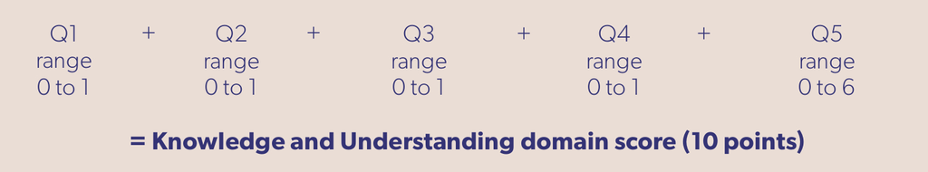

#### Physical activity guideline score

```r
capl_demo_data$pa_guideline_score <- get_binary_score(
  capl_demo_data$pa_guideline,
  c(3, "60 minutes or 1 hour")
)
```

```r
capl_demo_data$pa_guideline_score
```

```
#>   [1]  0  1  0  0  0  0  1  0  0  0  0  0  0  0  0  0  0  0  0  0  0  0  0  0  0
#>  [26]  1  1  0  0  0  0  0  0  1  1  0  0  0  0  1  0  0  0  1  0  1  0  0  1  0
#>  [51]  0  0  0  0  0  0  0  0  1  1  0  0  0  0  0  0  0  1  0  0  0  0  1  0  1
#>  [76]  0  0  0  1  1  1  0  0  1  0  0  1  0  0  1  0  1  0  0  1  1  0  0  0  1
#> [101]  0  0  1  0  1  0  1  0  0  0  0  0  0  0  0  1  0  0  0  1  1  1  1  0  1
#> [126]  0  0  0  0  0  1  0  0  0  0  0  1  0  0  1  1  0  0  1  1  1  0  0  0  0
#> [151]  0  0  0  0  0  0  1  1  0  0  0  1  0  1  0  0  0  0  0  1  0  1  0  0  0
#> [176]  0  1  0  1  0  0  1  1  0  0  0  0  0  1  0  0  0  0  0  0  0  0  0  0  1
#> [201]  0  1  0  0  0  0  1  1  0  0  0  0  0  0  1  0  0  0  1  0  0  0  0  0  0
#> [226]  0  0  0  0  0  0  1  1  0  0  0  0  0  0  0  1  0  0  1  1  1  0  0  1  0
#> [251] NA  1  0  1  0  0  0  0  0  1  1  1  0  1  0  1  0  0  0  0  1  0  0  0  0
#> [276]  0  0  0  0  0  0  1  0  0  0  0  1  0  0  0  0  0  0  0  0  0  0  1  1  0
#> [301]  0  1  1  1  0  0  0  0  0  0  0  0  1  0  0  0  0  0  0  0  0  0  0  1  0
#> [326]  0  1  0  0  0  0  0  0  0  0  0  0  0  0  0  0  0  0  1  0  1  0  1  0  1
#> [351]  1  1  0  0  0  1  0  0  0  0  1  1  0  0  0  1  1  0  0  0  0  0  0  0  0
#> [376]  1  0  0  0  0  0  1  1  0  0  0  1  1  0  1  0  1  0  0  0  0  1  0  0  0
#> [401]  1  0  0  1  0  0  0  1  0  0  1  0  0  1  0  1  0  0  0  0  0  0  0  0  0
#> [426]  0  1  1  0  1  0  0  0  0  1  0  0  0  0  0  0  1  1  0  0  1  0  1  1  0
#> [451]  0  1  1  0  0  0  0  0  1  0  0  0  0  0  1  1  0  0  0  0  0  1  0  1  0
#> [476]  0  0  0  1  0  0  0  1  0  0  0  0  0  0  0  0  0  0  0  0  0  0  1  0  0
```

#### Cardiorespiratory fitness definition score

```r
capl_demo_data$crf_means_score <- get_binary_score(
  capl_demo_data$crf_means,
  c(2, "How well the heart can pump blood and the lungs can provide oxygen")
)
```

```r
capl_demo_data$crf_means_score
```

```
#>   [1]  0  0  0  1  1  0  1  0  0  0  1  1  0  0  0  1  0  0  0  0  0  1  0  0  0
#>  [26]  0  0  0  0  1  0  0  0  0  0  0  0  0  0  0  0  0  0  0  0  0  0  1  0  0
#>  [51]  0  0  0  1  0  1  1  1  0  0  0  0  0  0  1  0  0  0  1  1  0  1  1  0  1
#>  [76]  0  0  0  0  0  1  1  0  0  0  0  0  0  0  0  0  1  0  0  0  0  0  0  0  1
#> [101]  1  1  1  1  0  0  0  0  0  0  0  0  0  0  0  0  1  0  1  0  0  0  0  0  0
#> [126]  0  0  0  0  0  0  0  1  0  0  0  0  0  0  0  1  1  0  1  1  0  0  0  0  1
#> [151]  0  0  0  1  0  1  0  0  0  1  1  1  1  0  0  0  0  0  0  0  0  0  0  0  0
#> [176]  0  0  1  1  0  0  0  0  0  0  0  1  1  0  0  0  1  1  1  0  0  0  1  0  0
#> [201]  0  0  0  0  0  0  0  0  0  0  0  0  0  0  0  0  0  0  0  0  0  1  0  1  0
#> [226]  0  1  0  1  1  0  0  0  0  1  1  0  0  0  0  1  0  0  0  0  0  0  0  0  1
#> [251]  0  0  0  0  0  0  0  1  0  1  0  0  0  1  0  0  0  0  0  0  0  0  0  1  0
#> [276]  0  1  1  0  1  0  0  0  0  0  0  0  0  0  0  1  1  0  1  0  0  1  0  0  0
#> [301]  1  1  0  1  1  0  1  0  0  1  0  0  0  0  1  0  0  1  0  0  1  0  0  0  0
#> [326]  0  1  0  0  1  0  0  0  1  0  1  0  0  0  0  0  0  0  0  0  0  0  0  0  0
#> [351]  0  0  0  0  0  1  0  1  0  0  0  0  1  0  0  0  0  0  0  1  0  0  0  1  1
#> [376]  1  0  0  1  0  0  0  1  0  0  0  0  0  0  0  0  0  0  0  0  0  0  1  0  0
#> [401]  0  0  0  0  0  0  0  1  0  1  1  0  1  1  0  0  0  0  0  1  0  1  0  0  1
#> [426]  1  0  0  0  1  0  1  0  0  0  0  0  0  0  0  0  0  0  0  0  0  1  1  0  1
#> [451]  0  0  1  1  0  0  1  1  0  0  0  0  1  1  1  0  0  0  1  0  0  0  0  1  0
#> [476]  0  0  0  1  1  1  0  0  0  0  0  0  0  1  0  0  1  0 NA  0  1  0  0  0  0
```

#### Muscular strength definition score

```r
capl_demo_data$ms_means_score <- get_binary_score(
  capl_demo_data$ms_means,
  c(1, "How well the muscles can push, pull or stretch")
)
```

```r
capl_demo_data$ms_means_score
```

```
#>   [1]  0  0  1  0  0  1  1  0  0  0  1  1  1  0  1  0  0  0  0  0  0  0  0  0  0
#>  [26]  0  0  0  0  0  0  0  0  0  0  0  0  0  0  0  0  0  1  0  1  0  0  0  0  0
#>  [51]  0  1  1  0  1  0  1  1  0  1  0  0  0  0  1  1  1  1  0  1  1  1  0  1  0
#>  [76]  0  0  0  0  0  0  0  1  0  0  0  0  1  0  0  1  0  1  0  1  0  0  0  0  0
#> [101]  1  0  0  0  0  0  0  0  0  0  1  0  0  1  0  1  1  0  0  0  1  1  1  0  0
#> [126]  0  0  1  0  1  0  0  0  0  0  0  0  0  0  0  0  0  0  0  0  0  0  1  0  0
#> [151]  0  0  0  1  0  1  0  0  1  1  0  0  1  0  0  1  1  0  0  0  0  0  0  1  1
#> [176]  1  0  0  0  0  1  1  0  1  0  1  0  0  0  0  0  0  0  0  0  0  0  0  0  0
#> [201]  0  0  0  0  0  0  0  0  1  0  0  0  0  0  1 NA  0  0  0  0  0  1  0  1  0
#> [226]  0  0  1  0  0  1  0  1  0  0  0  1  0  0  0  1  1  0  0  1  0  1  0  0  0
#> [251]  0  0  0  1  0  0  0  1  1  0  0  0  1  0  0  0  0  0  0  0  0  0  0  0  0
#> [276]  1  0  0  0  1  0  0  0  1  0  1  0  0  0  0  0  0  0  0  0  0  0  0  0  0
#> [301]  0  0  0  0  0  0  1  0  0  0  1  1  0  0  1  0  0  0  0  1  1  0  0  0  0
#> [326]  0  0  0  0  0  1  0  1  0  1  1  0  1  0  0  0  1  0  1  0  0  1  0  0  0
#> [351]  0  0  1  0  0  1  0  1  0  1  0  0  1  1  0  1  0  0  1  0  0  0  0  0  0
#> [376]  0  0  0  0  0  1  0  0  0  0  1  0  0  1  0  0  0  0  0  0  0  0  1  0  0
#> [401]  0  0  0  0  0  0  0  1  1  1  0  1 NA  0  0  0  1  1  0  0  0  0  1  0  0
#> [426]  0  1  1  0  0  1  0  0  0  1  0  0  1  0  1  0  1  0  0  0  0  0  0  0  0
#> [451]  1  0  1  0  0  0  0  0  1  0  1  1  0  0  1  1  0  1  0  0  1  1  1  0  0
#> [476]  0  0  0  0  1  1  0  0  1  1  1  0  0  1  0  0  0  0  0  0  0  0  1  1  0
```

#### Sports skill score

```r
capl_demo_data$sports_skill_score <- get_binary_score(
  capl_demo_data$sports_skill,
  c(4, "Watch a video, take a lesson or have a coach teach you how to kick and catch")
)
```

```r
capl_demo_data$sports_skill_score
```

```
#>   [1] 0 1 1 0 0 0 0 0 1 0 1 0 0 0 1 0 0 1 1 0 0 0 0 0 0 0 0 1 1 0 0 1 0 0 1 0 0
#>  [38] 0 0 0 0 0 0 0 0 1 0 1 0 0 0 0 0 0 0 0 1 0 0 0 0 0 0 0 0 0 1 1 1 0 0 0 0 0
#>  [75] 1 0 0 1 0 1 0 0 0 1 0 0 1 1 0 0 0 0 1 1 0 0 0 1 0 1 0 0 1 1 0 0 1 0 0 1 0
#> [112] 0 0 0 1 1 0 0 0 0 1 1 0 0 0 0 0 1 0 0 0 0 1 0 0 0 0 0 1 0 0 0 0 1 0 1 0 0
#> [149] 0 0 0 0 0 0 0 0 0 1 0 0 0 0 1 0 0 0 1 0 0 0 1 0 0 0 0 1 0 0 0 0 0 0 0 1 0
#> [186] 0 0 0 0 0 1 0 1 0 0 0 0 0 1 0 0 0 0 0 0 0 0 0 0 0 0 1 1 0 1 0 1 0 0 0 0 0
#> [223] 0 1 0 0 0 0 0 1 0 0 1 0 0 0 0 0 0 0 0 0 0 0 0 1 0 0 0 0 1 0 0 0 0 0 0 0 1
#> [260] 0 0 1 0 1 0 0 0 0 0 0 0 0 1 0 0 0 1 1 1 1 0 0 0 0 0 1 1 0 0 0 0 0 1 0 0 0
#> [297] 0 0 0 0 0 0 0 0 0 0 1 0 0 0 1 0 1 0 0 0 0 0 0 0 1 0 0 1 0 0 0 0 0 1 0 0 1
#> [334] 0 0 0 1 0 0 0 1 1 0 0 0 1 1 0 0 0 0 0 1 0 0 0 0 0 0 0 0 0 0 0 0 0 0 1 0 0
#> [371] 1 0 0 0 1 0 1 0 0 1 0 0 0 0 0 0 1 0 0 0 1 0 0 0 1 1 0 0 0 0 1 0 0 0 0 0 1
#> [408] 1 1 0 1 0 0 1 1 0 0 0 0 0 0 0 0 0 1 1 0 1 0 0 0 0 0 0 1 0 0 0 1 0 1 0 1 0
#> [445] 1 1 1 1 0 0 0 0 1 1 0 1 0 0 0 1 0 0 0 0 0 0 0 0 0 0 0 0 0 1 0 0 1 0 0 0 1
#> [482] 0 0 1 0 0 1 0 0 0 0 0 0 0 0 0 0 0 0 1
```

#### Fill in the blanks score

```r
capl_demo_data$fill_in_the_blanks_score <- get_fill_in_the_blanks_score(
  pa_is = capl_demo_data$pa_is,
  pa_is_also = capl_demo_data$pa_is_also,
  improve = capl_demo_data$improve,
  increase = capl_demo_data$increase,
  when_cooling_down = capl_demo_data$when_cooling_down,
  heart_rate = capl_demo_data$heart_rate
)
```

```r
capl_demo_data$fill_in_the_blanks_score
```

```
#>   [1] 1 5 2 5 5 3 3 3 3 4 5 4 3 4 4 3 2 2 3 4 3 3 4 1 5 4 6 4 4 4 4 4 1 4 4 2 4
#>  [38] 4 3 5 4 3 4 3 5 5 4 5 2 3 4 4 2 3 6 3 3 5 5 2 6 2 2 4 2 4 3 3 6 2 3 5 5 3
#>  [75] 3 2 5 2 3 3 5 4 4 4 5 5 2 3 4 3 4 5 3 1 5 5 5 4 4 4 5 3 4 2 0 3 3 4 4 3 3
#> [112] 5 3 4 4 2 2 3 6 4 3 5 5 2 3 3 5 5 3 6 4 3 2 3 3 0 3 4 3 3 3 3 4 3 3 2 5 5
#> [149] 4 5 4 3 3 5 0 3 3 4 4 2 2 3 4 1 3 3 2 3 6 3 4 4 4 6 2 4 2 3 2 5 4 3 2 5 5
#> [186] 5 3 2 5 3 3 3 3 5 6 2 4 4 3 4 4 2 5 2 4 3 4 4 1 4 3 5 4 3 3 4 3 2 0 5 4 4
#> [223] 4 5 3 6 2 5 4 2 3 3 2 4 3 4 3 2 5 3 3 5 3 3 4 5 0 3 4 4 4 4 1 2 4 4 2 3 1
#> [260] 3 5 2 3 5 4 1 3 3 3 4 3 3 3 4 3 4 5 0 5 3 3 3 3 5 6 5 3 4 3 3 6 6 2 1 2 2
#> [297] 3 5 4 4 2 1 1 1 5 2 2 5 4 3 5 4 6 3 5 2 5 3 2 5 4 5 4 4 1 3 4 6 3 3 3 5 5
#> [334] 2 3 4 3 5 5 4 4 0 4 3 4 3 3 3 4 2 3 2 3 6 5 3 5 2 4 4 5 3 2 4 3 2 3 3 5 2
#> [371] 3 3 5 6 3 3 2 5 4 4 5 4 5 4 3 2 3 5 3 5 2 4 4 4 3 2 4 3 3 2 4 3 3 3 4 2 3
#> [408] 5 2 4 3 2 4 3 3 3 3 5 3 3 4 2 4 2 4 4 5 3 3 3 3 6 5 3 4 1 4 4 5 4 2 2 2 3
#> [445] 2 4 4 4 4 1 4 3 1 5 2 5 2 6 2 6 5 3 4 2 3 4 4 3 4 4 2 3 4 2 3 3 4 3 3 4 5
#> [482] 6 5 5 6 2 4 4 3 4 2 2 3 1 3 2 3 2 3 2
```

#### Knowledge and understanding score

The `get_ku_score()` function computes a knowledge and understanding domain score that ranges from zero to 10 based on the physical activity guideline (Q1), cardiorespiratory fitness means (Q2), muscular strength and endurance means (Q3), sports skill (Q4) and fill in the blanks (Q5) scores. If one of the scores is missing or invalid, a weighted domain score will be computed from the other four scores. This score is used to compute the overall physical literacy score.

```r
capl_demo_data$ku_score <- get_ku_score(
  pa_guideline_score = capl_demo_data$pa_guideline_score,
  crf_means_score = capl_demo_data$crf_means_score,
  ms_means_score = capl_demo_data$ms_means_score,
  sports_skill_score = capl_demo_data$sports_skill_score,
  fill_in_the_blanks_score = capl_demo_data$fill_in_the_blanks_score
)
```

```r
capl_demo_data$ku_score
```

```
#>   [1] 1.000000 7.000000 4.000000 6.000000 6.000000 4.000000 6.000000 3.000000
#>   [9] 4.000000 4.000000 8.000000 6.000000 4.000000 4.000000 6.000000 4.000000
#>  [17] 2.000000 3.000000 4.000000 4.000000 3.000000 4.000000 4.000000 1.000000
#>  [25] 5.000000 5.000000 7.000000 5.000000 5.000000 5.000000 4.000000 5.000000
#>  [33] 1.000000 5.000000 6.000000 2.000000 4.000000 4.000000 3.000000 6.000000
#>  [41] 4.000000 3.000000 5.000000 4.000000 6.000000 7.000000 4.000000 7.000000
#>  [49] 3.000000 3.000000 4.000000 5.000000 3.000000 4.000000 7.000000 4.000000
#>  [57] 6.000000 7.000000 6.000000 4.000000 6.000000 2.000000 2.000000 4.000000
#>  [65] 4.000000 5.000000 5.000000 6.000000 8.000000 4.000000 4.000000 7.000000
#>  [73] 7.000000 4.000000 6.000000 2.000000 5.000000 3.000000 4.000000 5.000000
#>  [81] 7.000000 5.000000 5.000000 6.000000 5.000000 5.000000 4.000000 5.000000
#>  [89] 4.000000 4.000000 5.000000 7.000000 5.000000 2.000000 7.000000 6.000000
#>  [97] 5.000000 5.000000 4.000000 7.000000 7.000000 4.000000 7.000000 4.000000
#> [105] 1.000000 3.000000 5.000000 4.000000 4.000000 4.000000 4.000000 5.000000
#> [113] 3.000000 5.000000 5.000000 5.000000 4.000000 3.000000 7.000000 5.000000
```

[output cut: 48 more lines]

#### Knowledge and understanding interpretation

The `get_capl_interpretation()` function computes an age- and gender-specific CAPL-2 interpretation for a given CAPL-2 protocol or domain score.

```r
capl_demo_data$ku_interpretation <- get_capl_interpretation(
  age = capl_demo_data$age,
  gender = capl_demo_data$gender,
  score = capl_demo_data$ku_score,
  protocol = "ku"
)
```

```r
capl_demo_data$ku_interpretation
```

```
#>   [1] "beginning"   "achieving"   "beginning"   "progressing" "progressing"
#>   [6] "beginning"   "progressing" "beginning"   "beginning"   "beginning"
#>  [11] NA            "progressing" NA            NA            "progressing"
#>  [16] "beginning"   "beginning"   "beginning"   "beginning"   "beginning"
#>  [21] "beginning"   "beginning"   "beginning"   NA            NA
#>  [26] NA            "progressing" NA            "beginning"   "progressing"
#>  [31] "beginning"   "beginning"   "beginning"   NA            "progressing"
#>  [36] NA            NA            "beginning"   "beginning"   "progressing"
#>  [41] "beginning"   "beginning"   "progressing" "beginning"   "progressing"
#>  [46] "achieving"   "beginning"   "achieving"   NA            NA
#>  [51] "beginning"   "beginning"   "beginning"   "beginning"   "achieving"
#>  [56] "beginning"   "progressing" "achieving"   "progressing" "beginning"
#>  [61] "progressing" NA            "beginning"   "beginning"   "beginning"
#>  [66] NA            "progressing" "progressing" NA            "beginning"
#>  [71] "beginning"   "achieving"   "progressing" "beginning"   NA
```

[output cut: 85 more lines]

#### Knowledge and understanding domain status

The `get_capl_domain_status()` function computes the status (“complete”, “missing interpretation”, “missing protocol” or “incomplete”) of a CAPL domain.

```r
capl_demo_data$ku_status <- get_capl_domain_status(
  x = capl_demo_data,
  domain = "ku"
)
```

```r
capl_demo_data$ku_status
```

```
#>   [1] "complete"               "complete"               "complete"
#>   [4] "complete"               "complete"               "complete"
#>   [7] "complete"               "complete"               "complete"
#>  [10] "complete"               "missing interpretation" "complete"
#>  [13] "missing interpretation" "missing interpretation" "complete"
#>  [16] "complete"               "complete"               "complete"
#>  [19] "complete"               "complete"               "complete"
#>  [22] "complete"               "complete"               "missing interpretation"
#>  [25] "missing interpretation" "missing interpretation" "complete"
#>  [28] "missing interpretation" "complete"               "complete"
#>  [31] "complete"               "complete"               "complete"
#>  [34] "missing interpretation" "complete"               "missing interpretation"
#>  [37] "missing interpretation" "complete"               "complete"
#>  [40] "complete"               "complete"               "complete"
#>  [43] "complete"               "complete"               "complete"
```

[output cut: 152 more lines]

### Overall physical literacy functions

As illustrated in [the CAPL-2 manual](https://www.capl-eclp.ca/wp-content/uploads/2017/10/capl-2-manual-en.pdf) on page 17, the formula for computing the overall physical literacy score is:

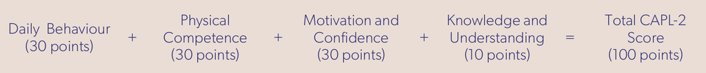

#### Overall physical literacy score

The `get_capl_score()` function computes an overall physical literacy score that ranges from zero to 100 based on the physical competence, daily behaviour, motivation and confidence, and knowledge and understanding domain scores. If one of the scores is missing or invalid, a weighted score will be computed from the other three scores.

```r
capl_demo_data$capl_score <- get_capl_score(
  pc_score = capl_demo_data$pc_score,
  db_score = capl_demo_data$db_score,
  mc_score = capl_demo_data$mc_score,
  ku_score = capl_demo_data$ku_score
)
```

```r
capl_demo_data$capl_score
```

```
#>   [1] 54.28571 76.90000 60.00000 68.80000 79.00000 63.00000 52.00000 71.26667
#>   [9] 58.40000 74.66667 83.14286 67.90000 67.50000 57.10000 54.85714 83.60000
#>  [17] 74.60000 77.10000 68.40000 78.80000 75.00000 71.40000 70.83333 64.42857
#>  [25] 68.10000 80.46667 83.30000 68.20000 79.10000 71.30000 65.60000 51.50000
#>  [33] 65.60000 69.23333 79.33333 77.40000 74.20000 80.00000 77.10000 61.10000
#>  [41] 69.30000 81.50000 68.00000 84.50000 81.42857 73.00000 52.00000 86.38095
#>  [49] 64.30000 68.93333 70.10000 83.33333 74.40000 75.50000 79.86667 82.30000
#>  [57] 62.90000 79.20000 86.13333 71.70000 82.50000 67.80000 59.50000 68.14286
#>  [65] 65.80000 79.40000 32.90000 76.30000 71.60000 64.14286 73.04762 67.70000
#>  [73] 71.20000 69.71429 67.50000 75.60000 69.40000 47.40000 60.00000 51.28571
#>  [81] 71.80000 78.20000 71.20000 69.10000 65.30000 74.76667 78.00000 88.57143
#>  [89] 69.90000 58.10000 62.10000 81.30000 74.00000 74.90000 51.60000 75.26667
#>  [97] 76.50000 67.90000 77.30000 77.42857 77.40000 77.30000 67.50000 79.30000
#> [105] 61.30000 52.40000 65.36667 78.10000       NA 59.70000 81.80000 61.16667
#> [113] 82.40000 81.20000 55.40000 72.14286 75.10000 71.20000 68.60000 61.60000
```

[output cut: 48 more lines]

#### Overall physical literacy interpretation

The `get_capl_interpretation()` function computes an age- and gender-specific CAPL-2 interpretation for a given CAPL-2 protocol or domain score.

```r
capl_demo_data$capl_interpretation <- get_capl_interpretation(
  age = capl_demo_data$age,
  gender = capl_demo_data$gender,
  score = capl_demo_data$capl_score,
  protocol = "capl"
)
```

```r
capl_demo_data$capl_interpretation
```

```
#>   [1] "progressing" "excelling"   "progressing" "achieving"   "achieving"
#>   [6] "progressing" "beginning"   "achieving"   "progressing" "excelling"
#>  [11] NA            "progressing" NA            NA            "progressing"
#>  [16] "excelling"   "achieving"   "excelling"   "progressing" "excelling"
#>  [21] "achieving"   "achieving"   "achieving"   NA            NA
#>  [26] NA            "excelling"   NA            "excelling"   "achieving"
#>  [31] "progressing" "progressing" "progressing" NA            "excelling"
#>  [36] NA            NA            "excelling"   "excelling"   "progressing"
#>  [41] "achieving"   "excelling"   "achieving"   "excelling"   "excelling"
#>  [46] "achieving"   "progressing" "excelling"   NA            NA
#>  [51] "achieving"   "excelling"   "excelling"   "achieving"   "excelling"
#>  [56] "excelling"   "progressing" "excelling"   "excelling"   "achieving"
#>  [61] "excelling"   NA            "progressing" "achieving"   "achieving"
#>  [66] NA            "beginning"   "excelling"   NA            "progressing"
#>  [71] "excelling"   "achieving"   "achieving"   "achieving"   NA
```

[output cut: 85 more lines]

#### Overall physical literacy domain status

The `get_capl_domain_status()` function computes the status (“complete”, “missing interpretation”, “missing protocol” or “incomplete”) of a CAPL domain.

```r
capl_demo_data$capl_status <- get_capl_domain_status(
  x = capl_demo_data,
  domain = "capl"
)
```

```r
capl_demo_data$capl_status
```

```
#>   [1] "missing protocol"       "complete"               "complete"
#>   [4] "complete"               "complete"               "complete"
#>   [7] "missing protocol"       "complete"               "complete"
#>  [10] "missing protocol"       "missing interpretation" "complete"
#>  [13] "missing interpretation" "missing interpretation" "missing protocol"
#>  [16] "complete"               "complete"               "complete"
#>  [19] "complete"               "complete"               "complete"
#>  [22] "complete"               "complete"               "missing interpretation"
#>  [25] "missing interpretation" "missing interpretation" "complete"
#>  [28] "missing interpretation" "complete"               "complete"
#>  [31] "complete"               "complete"               "complete"
#>  [34] "missing interpretation" "complete"               "missing interpretation"
#>  [37] "missing interpretation" "missing protocol"       "complete"
#>  [40] "complete"               "complete"               "complete"
#>  [43] "complete"               "complete"               "missing protocol"
```

[output cut: 152 more lines]

## Data visualization

The `capl` package makes use of the famous `ggplot2` R package to create custom functions that render beautiful plots for visualizing CAPL-2 results.

### Plots

CAPL-2 scores can be grouped by their associated interpretative categories and visualized in a bar plot by calling the `get_capl_bar_plot()` function. The mean score for each interpretative category appears above each bar.

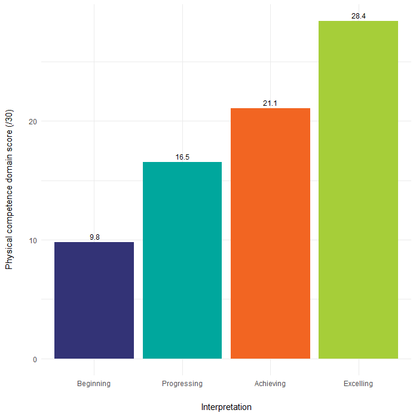

```r
get_capl_bar_plot(
  score = capl_results$pc_score,
  interpretation = capl_results$pc_interpretation,
  x_label = "Interpretation",
  y_label = "Physical competence domain score (/30)"
)
```

The color palette can be customized by setting the `colors` parameter.

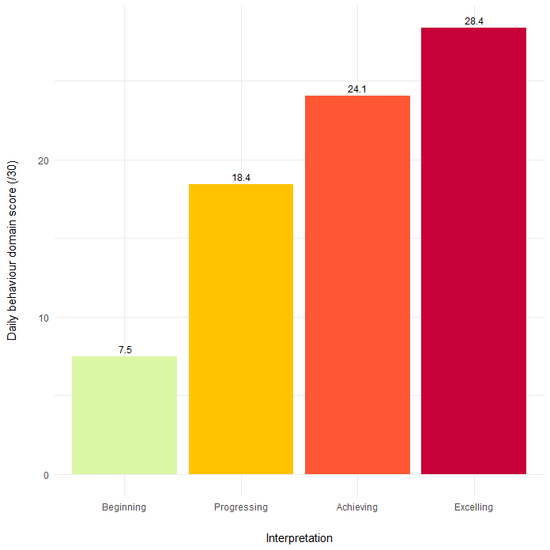

```r
get_capl_bar_plot(
  score = capl_results$db_score,
  interpretation = capl_results$db_interpretation,
  x_label = "Interpretation",
  y_label = "Daily behaviour domain score (/30)",
  colors = c("#daf7a6", "#ffc300", "#ff5733", "#c70039")
)
```

## Export results

If users want to export their data, the `export_capl_data()` function allows them to export their data to Excel or SPSS.

```r
export_capl_data(
  x = capl_results,
  file_path = "c:/path/to/store/capl-results.xlsx"
)

export_capl_data(
  x = capl_results,
  type = "spss",
  file_path = "c:/path/to/store/capl-results.sav"
)
```